# Construct-validity SEM: fit diagnostics

- Show All Code
- Hide All Code
- View Source

Reviewer response support — are the misfit and the high factor correlations statistical artifacts?

Author

LEVANTE core tasks manuscript

Published

October 23, 2026

**NoteWhat this notebook is, and how the manuscript now stands**

Both reviewers flagged the construct-validity SEM: overall fit below conventional thresholds, and very high correlations among Reasoning, Executive Function and Language. Checks 1–6 below test whether those two problems could be statistical artifacts — of model size, sample size, IRT measurement error, pooling across sites, or the missingness pattern. They are not: the misfit and the high correlations are real features of these data.

That conclusion is what shapes the manuscript’s current treatment:

- **Factor structure is reported but not interpreted.** The manuscript gives the inter-factor correlations descriptively and defers the question of what they mean, because those results are reserved for a dedicated paper in preparation. The bifactor / Schmid-Leiman appendix and the factor-count comparison table were removed for that reason. `_09-bifactor.qmd` is still in the repo and still runs, and `ms.qmd` carries a commented block showing how to restore the appendix.
- **The external-validity models changed as a result of the last section of this notebook.** Figures 7 and 8 now show the measurement model without age (spec A), and Table 8 reports loadings with and without an age control (spec A versus spec C). The earlier `factor ~ age` specification (spec B) was dropped.

Everything here re-runs the manuscript’s own chunks rather than a stand-in copy, so the numbers are the paper’s own and stay in sync when `_08-sem.qmd` changes.

```r
library(here)

# Everything below assumes the repo root as the working directory: the chunks
# we borrow from _08-sem.qmd use paths like "sem/layouts/..." that are written
# relative to where ms.qmd renders from, not relative to this file's folder.
knitr::opts_knit$set(root.dir = here::here())
```

```r
library(tidyverse)
library(glue)
library(lavaan)
library(MASS, include.only = "mvrnorm")

# Needed only by the chunks borrowed from _10-subsample-robustness.qmd in
# Check 4, which format their output with flextable.
library(flextable)

theme_set(theme_minimal(base_size = 11))
```

**NoteSetup — parameters, model rebuilding, and simulation machinery (click to expand)**

## Knobs

Replication counts are set here. All simulations are seeded, so a given setting reproduces exactly.

The defaults require approximately 5,000 model fits (roughly 40 minutes), dominated by the sample-size sweep in Check 2. Chunks are cached, so re-rendering repeats only what changed. Reduced settings (60 and 40 replicates, two-point sweep) complete in a few minutes and yield the same qualitative conclusions.

```r
N_REPS_NULL  <- 500   # replicates per null-fit simulation (check 1 & 2)
N_REPS_ME    <- 300   # replicates per measurement-error condition (check 3)
SEED         <- 20260207

# Sample sizes used for the "does N drive the fit indices?" sweep in check 2.
# The real analysis N is spliced in automatically below.
N_SWEEP_EXTRA <- c(300, 600, 1200, 4000)
```

## Rebuilding the manuscript’s models

### Locating the sibling repositories

`ms.qmd` sets `levante_dir <- here("../..")` and reads scores from `levante-pilots`. This notebook resolves that location rather than hardcoding the offset, testing `../..` first so it matches `ms.qmd` where that layout holds.

`ms.qmd` also sources `levante-data-meta/plot_settings.R`, which sets ggplot themes and palettes only. No chunk used here produces a figure that depends on it, so it is sourced if present and skipped otherwise.

```r
find_levante_dir <- function() {
  candidates <- c(here("../.."), here(".."))
  has_pilots <- dir.exists(file.path(candidates, "levante-pilots"))
  if (!any(has_pilots)) {
    stop(glue(
      "Could not find `levante-pilots`.\nLooked in:\n",
      paste0("  - ", normalizePath(candidates, mustWork = FALSE), collapse = "\n"),
      "\n\nThis notebook reruns the real models from _08-sem.qmd, so it needs ",
      "the same scores `ms.qmd` reads. Clone levante-pilots next to this repo ",
      "(or next to its parent) and re-render."
    ), call. = FALSE)
  }
  normalizePath(candidates[has_pilots][1])
}

levante_dir <- find_levante_dir()
pilots_dir  <- file.path(levante_dir, "levante-pilots")

# Cosmetic only (ggplot theme + palettes); nothing here depends on it.
# `_02-scores.qmd` calls `filter_out()`, which comes from dplyr (>= 1.2.0),
# not from this file.
# Sourced best-effort: it pulls in ggthemes/sysfonts/showtext, which renv cannot
# see (they are reached through source(), not a library() call), so a fresh
# project library may not have them. Nothing below depends on it.
plot_settings <- file.path(levante_dir, "levante-data-meta", "plot_settings.R")
if (file.exists(plot_settings)) {
  tryCatch(source(plot_settings), error = function(e) {
    message("Skipped plot_settings.R (cosmetic only): ", conditionMessage(e))
  })
}

if (packageVersion("dplyr") < "1.2.0") {
  stop(glue(
    "dplyr {packageVersion('dplyr')} is too old: `_02-scores.qmd` uses ",
    "dplyr::filter_out(), added in 1.2.0."
  ), call. = FALSE)
}

glue("levante_dir: {levante_dir}")
```

```
#> levante_dir: /Users/foreilly/Documents/GitHub
```

The scores pipeline reads `levante-pilots/01_fetched_data/`, which is gitignored upstream. If it is absent, the next chunk fails; the remedy is to re-run the fetch step in `levante-pilots`.

```r
required_inputs <- file.path(pilots_dir, c(
  "01_fetched_data/runs_filtered_trials.rds",
  "02_scoring_outputs/scores/registry_scores.rds",
  "02_scoring_outputs/mod_stats.rds",
  "02_scoring_outputs/scores/scores_custom.rds"
))

missing_inputs <- required_inputs[!file.exists(required_inputs)]
if (length(missing_inputs)) {
  stop(glue(
    "Missing upstream input(s):\n",
    paste0("  - ", missing_inputs, collapse = "\n"),
    "\n\n`01_fetched_data/` is gitignored in levante-pilots; re-run the data ",
    "fetch there before rendering this notebook."
  ), call. = FALSE)
}

cat("All upstream inputs present.\n")
```

```
#> All upstream inputs present.
```

### Borrowing the real chunks

`read_qmd_chunks()` extracts named chunks from a `.qmd` verbatim. The models below are therefore the manuscript’s own specifications, and track subsequent edits to `_08-sem.qmd` rather than diverging from them.

````r
read_qmd_chunks <- function(path, labels) {
  lines <- readLines(path, warn = FALSE)
  opens <- grep("^```\\{r[ ,}]", lines)
  closes <- grep("^```[[:space:]]*$", lines)

  found <- map(opens, function(open) {
    close <- closes[closes > open]
    if (!length(close)) {
      stop(glue("Unterminated chunk at {basename(path)}:{open}"), call. = FALSE)
    }
    close <- close[1]
    header <- lines[open]
    # label from either ```{r my-label, ...} or a #| label: my-label option line
    label <- str_match(header, "^```\\{r[ ]+([^,}[:space:]]+)")[, 2]
    body <- if (close > open + 1) lines[(open + 1):(close - 1)] else character(0)
    if (is.na(label)) {
      label <- str_match(body, "^#\\|\\s*label:\\s*(\\S+)")[, 2] |>
        discard(is.na) |>
        first()
    }
    list(label = label, body = body)
  })

  available <- map_chr(found, \(c) c$label %||% NA_character_)
  unknown <- setdiff(labels, available)
  if (length(unknown)) {
    stop(glue(
      "Chunk(s) {paste(sQuote(unknown), collapse = ', ')} not found in ",
      "{basename(path)}. Available: {paste(sQuote(na.omit(available)), collapse = ', ')}.\n",
      "The upstream file was probably restructured -- update the chunk list ",
      "in this notebook to match."
    ), call. = FALSE)
  }

  found[match(labels, available)]
}

run_qmd_chunks <- function(path, labels, envir = globalenv()) {
  for (chunk in read_qmd_chunks(path, labels)) {
    eval(parse(text = paste(chunk$body, collapse = "\n")), envir = envir)
  }
  invisible(labels)
}
````

```r
run_qmd_chunks(here("_01-tasks.qmd"),  "task-info")
run_qmd_chunks(here("_02-scores.qmd"), c("filter-params", "load-scores"))
run_qmd_chunks(here("_06-reliability.qmd"), "load-rxx")

# prep-sem      -> wide_scores
# sem-g-age     -> model_cov_age, fit_cov_age   (the Figure 6 model)
# sem-factors   -> mdl_1f/2f/3f, fit_1f/2f/3f, fit_tbl, grab_fit()
#
# The plotting chunks (sem-g-plot, sem-ef-*, sem-lang-*) are deliberately
# skipped: they need tidySEM and the Excel layout files and produce nothing
# these diagnostics use.
run_qmd_chunks(here("_08-sem.qmd"), c("prep-sem", "sem-g-age", "sem-factors"))

stopifnot(
  exists("wide_scores"), exists("fit_cov_age"), exists("fit_3f"),
  lavInspect(fit_cov_age, "converged"), lavInspect(fit_3f, "converged")
)

glue("wide_scores: {nrow(wide_scores)} rows x {ncol(wide_scores)} cols")
```

```
#> wide_scores: 2030 rows x 13 cols
```

### The two models under discussion

The two reported problems attach to different fitted objects:

- **Overall misfit (CFI, RMSEA): `fit_cov_age`.** The model shown in Figure 6 (`fig-semplot-core-tasks`): three first-order factors, Stories as an observed endogenous outcome, Math as a single-indicator latent whose residual is fixed at 1 - rxx, and age predicting each factor and outcome. Identified with `std.lv = TRUE`. The CFI and RMSEA quoted in the manuscript come from this fit. (When these checks were first run, Math was also an observed outcome and the model used marker-variable identification. Both changes are reparameterisations or affect one fixed residual only; df, CFI and RMSEA are unchanged, so the checks below still apply.)
- **Factor correlations: `fit_3f`.** A three-factor model that treats Math and Stories as indicators of Reasoning and Language. It is no longer reported in the manuscript – the factor-count table that once showed it was removed – but it is still built in `_08-sem.qmd` because `_10-subsample-robustness.qmd` refits it, and `_09-bifactor.qmd` needs it if that appendix is restored.

Checks 1, 2 and 5 target `fit_cov_age`; Checks 3, 4 and 6 target `fit_3f`.

```r
grab_measures <- function(fit, label) {
  m <- fitMeasures(fit)
  pick <- function(nm) if (nm %in% names(m)) unname(m[[nm]]) else NA_real_
  tibble(
    model        = label,
    n            = pick("ntotal"),
    npar         = pick("npar"),
    df           = pick("df"),
    chisq        = pick("chisq"),
    chisq_p      = pick("pvalue"),
    cfi          = pick("cfi"),
    cfi_scaled   = pick("cfi.scaled"),
    tli          = pick("tli"),
    rmsea        = pick("rmsea"),
    rmsea_scaled = pick("rmsea.scaled"),
    rmsea_lo     = pick("rmsea.ci.lower"),
    rmsea_hi     = pick("rmsea.ci.upper"),
    rmsea_pclose = pick("rmsea.pvalue"),
    srmr         = pick("srmr"),
    chisq_scaled = pick("chisq.scaled"),
    cfi_robust   = pick("cfi.robust"),
    rmsea_robust = pick("rmsea.robust")
  )
}
```

```r
real_fits <- bind_rows(
  grab_measures(fit_cov_age, "fit_cov_age (Figure 6)"),
  grab_measures(fit_3f,      "fit_3f (Table: alt models)")
)

real_fits |> mutate(across(where(is.double), \(x) round(x, 3)))
```

| model | n | npar | df | chisq | chisq_p | cfi | tli | rmsea | rmsea_lo | rmsea_hi | rmsea_pclose | srmr | chisq_scaled | cfi_robust | rmsea_robust |
| --- | --- | --- | --- | --- | --- | --- | --- | --- | --- | --- | --- | --- | --- | --- | --- |
| fit_cov_age (Figure 6) | 2030 | 40 | 23 | 294.613 | 0 | 0.949 | 0.901 | 0.076 | 0.069 | 0.084 | 0 | 0.061 | 269.752 | 0.921 | 0.136 |
| fit_3f (Table: alt models) | 2030 | 33 | 30 | 371.316 | 0 | 0.936 | 0.904 | 0.075 | 0.068 | 0.082 | 0 | 0.063 | 333.379 | 0.908 | 0.129 |

Both models are estimated with `MLR`, so `lavaan` reports naive, scaled and robust variants of each index. The manuscript quotes the naive values, and the simulations below calibrate against those. The scaled values are the conventional choice under MLR; here they differ negligibly from the naive ones. The robust RMSEA is substantially larger than both, which is a known sensitivity of that statistic under FIML with extensive missing data (see Check 5) and is not interpreted here.

```r
fig6 <- real_fits |> filter(str_starts(model, "fit_cov_age"))
f3   <- real_fits |> filter(str_starts(model, "fit_3f"))

N_REAL  <- fig6$n
DF_REAL <- fig6$df

glue(
  "Figure 6 model: N = {N_REAL}, df = {DF_REAL}, ",
  "chi-square = {round(fig6$chisq, 1)} (p = {format.pval(fig6$chisq_p, digits = 3)}), ",
  "CFI = {round(fig6$cfi, 3)}, RMSEA = {round(fig6$rmsea, 3)} ",
  "[{round(fig6$rmsea_lo, 3)}, {round(fig6$rmsea_hi, 3)}]"
)
```

```
#> Figure 6 model: N = 2030, df = 23, chi-square = 294.6 (p = <2e-16), CFI = 0.949, RMSEA = 0.076 [0.069, 0.084]
```

## Simulation machinery

`refit_like()` re-estimates a model on new data using the original `lavaan` call, so estimator, missing-data handling, identification and optimizer settings are identical between the observed and simulated fits.

```r
# Re-estimate `fit`'s model on `newdata`, reusing its original lavaan call.
refit_like <- function(fit, newdata, ...) {
  cl <- fit@call
  cl[["data"]] <- quote(.newdata)
  overrides <- list(...)
  for (nm in names(overrides)) cl[[nm]] <- overrides[[nm]]
  .newdata <- newdata
  eval(cl, envir = environment())
}

# lavInspect(.., "converged") only tells us the optimizer stopped. Small or
# unlucky samples can stop at an inadmissible solution (negative residual
# variances, |r| > 1), which should count as a failure, not a datapoint.
# Same criterion _10-subsample-robustness.qmd uses.
# lavaan emits a warning when post.check fails; we are deliberately testing for
# that, so suppress the warning here and account for the discards instead.
fit_is_proper <- function(fit) {
  isTRUE(lavInspect(fit, "converged")) &&
    isTRUE(suppressWarnings(lavInspect(fit, "post.check")))
}

# Observed-variable data actually used by a fit, as a data frame (NAs intact).
model_data <- function(fit) {
  as.data.frame(lavInspect(fit, "data"))
}
```

`simulate_null()` draws samples from a population in which the fitted model holds exactly, then refits. Population moments are the fitted model’s own implied mean and covariance, so population parameter values equal the manuscript’s estimates. Any misfit in the resulting samples reflects sampling variation alone, at the observed df and N.

```r
# Draw from the model-implied moments of `fit` (where the model holds exactly),
# refit, and return the fit indices. `impose_missing` copies the real
# missingness pattern onto the simulated data by resampling rows of the real
# data's NA mask, so simulated samples carry the same information loss the
# real FIML fit does -- without it, simulated N is effectively larger than real
# N and the null would be optimistic.
simulate_null <- function(fit, n_reps, n_obs = NULL, impose_missing = TRUE,
                          seed = SEED, label = "") {
  base <- refit_like(fit, model_data(fit), fixed.x = FALSE)

  # fixed.x = FALSE makes exogenous variables (age_c) part of the modelled
  # moments so the implied covariance covers every observed variable. It adds
  # parameters and moments in equal number, so df and chi-square are untouched.
  stopifnot(
    all.equal(fitMeasures(base)[["df"]],    fitMeasures(fit)[["df"]]),
    isTRUE(all.equal(fitMeasures(base)[["chisq"]], fitMeasures(fit)[["chisq"]],
                     tolerance = 1e-4))
  )

  implied <- lavInspect(base, "implied")
  Sigma <- as.matrix(implied$cov)
  mu <- if (!is.null(implied$mean)) as.numeric(implied$mean) else rep(0, ncol(Sigma))
  vars <- colnames(Sigma)

  template <- model_data(base)[, vars, drop = FALSE]
  if (is.null(n_obs)) n_obs <- nrow(template)

  stopifnot(setequal(vars, colnames(template)))

  set.seed(seed)
  reps <- map(seq_len(n_reps), function(i) {
    sim <- mvrnorm(n_obs, mu = mu, Sigma = Sigma)
    colnames(sim) <- vars
    sim <- as.data.frame(sim)

    if (impose_missing) {
      rows <- sample(nrow(template), n_obs, replace = TRUE)
      sim[is.na(template[rows, , drop = FALSE])] <- NA_real_
    }

    fit_i <- tryCatch(refit_like(base, sim, fixed.x = FALSE),
                      error = function(e) NULL)
    if (is.null(fit_i) || !fit_is_proper(fit_i)) return(NULL)
    grab_measures(fit_i, label) |> mutate(rep = i, n_obs = n_obs)
  })

  n_ok <- sum(!map_lgl(reps, is.null))
  if (n_ok < n_reps * 0.9) {
    warning(glue(
      "{label}: only {n_ok} of {n_reps} replicates produced a proper solution ",
      "at n = {n_obs}. Treat the summary below as provisional."
    ))
  }

  reps |> compact() |> bind_rows() |> mutate(n_attempted = n_reps, n_proper = n_ok)
}
```

## Check 1 — Is the RMSEA inflated because the model has few df?

Kenny, Kaniskan and McCoach (2015, *Sociological Methods & Research*) show that RMSEA is upwardly biased and unstable when df is small, and recommend against reporting it below approximately df = 5. This check establishes whether the present model falls in that regime.

```r
glue("Figure 6 model df = {DF_REAL}")
```

```
#> Figure 6 model df = 23
```

```r
null_fig6 <- simulate_null(
  fit_cov_age, n_reps = N_REPS_NULL, seed = SEED,
  label = "fit_cov_age null"
)

null_summary <- function(sims) {
  sims |>
    summarise(
      across(
        c(chisq, cfi, rmsea, srmr),
        list(
          mean = \(x) mean(x, na.rm = TRUE),
          median = \(x) median(x, na.rm = TRUE),
          q95 = \(x) quantile(x, .95, na.rm = TRUE),
          q99 = \(x) quantile(x, .99, na.rm = TRUE),
          max = \(x) max(x, na.rm = TRUE)
        ),
        .names = "{.col}__{.fn}"
      ),
      n_proper = first(n_proper), n_attempted = first(n_attempted)
    ) |>
    pivot_longer(contains("__"), names_to = c("index", "stat"), names_sep = "__") |>
    pivot_wider(names_from = stat, values_from = value)
}

null_summary(null_fig6) |> mutate(across(where(is.double), \(x) round(x, 4)))
```

| n_proper | n_attempted | index | mean | median | q95 | q99 | max |
| --- | --- | --- | --- | --- | --- | --- | --- |
| 464 | 500 | chisq | 22.7122 | 22.2273 | 34.5654 | 40.6532 | 52.4209 |
| 464 | 500 | cfi | 0.9995 | 1.0000 | 1.0000 | 1.0000 | 1.0000 |
| 464 | 500 | rmsea | 0.0045 | 0.0000 | 0.0157 | 0.0194 | 0.0251 |
| 464 | 500 | srmr | 0.0119 | 0.0119 | 0.0152 | 0.0171 | 0.0201 |

Position of the observed values within the null distribution:

```r
pctile <- function(sims, index, observed) {
  mean(sims[[index]] >= observed, na.rm = TRUE)
}

tibble(
  index = c("rmsea", "cfi", "chisq"),
  observed = c(fig6$rmsea, fig6$cfi, fig6$chisq),
  null_median = c(median(null_fig6$rmsea), median(null_fig6$cfi), median(null_fig6$chisq)),
  p_null_as_extreme = c(
    pctile(null_fig6, "rmsea", fig6$rmsea),
    mean(null_fig6$cfi <= fig6$cfi, na.rm = TRUE),   # CFI: worse means lower
    pctile(null_fig6, "chisq", fig6$chisq)
  )
) |>
  mutate(across(where(is.double), \(x) round(x, 4)))
```

| index | observed | null_median | p_null_as_extreme |
| --- | --- | --- | --- |
| rmsea | 0.0763 | 0.0000 | 0 |
| cfi | 0.9492 | 1.0000 | 0 |
| chisq | 294.6129 | 22.2273 | 0 |

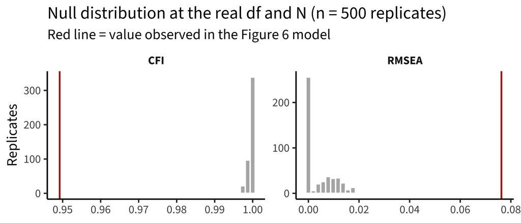

```r
null_fig6 |>
  dplyr::select(rep, rmsea, cfi) |>
  pivot_longer(c(rmsea, cfi), names_to = "index", values_to = "value") |>
  mutate(index = recode(index, rmsea = "RMSEA", cfi = "CFI")) |>
  ggplot(aes(value)) +
  geom_histogram(bins = 40, fill = "grey70", colour = "white") +
  geom_vline(
    data = tibble(index = c("RMSEA", "CFI"), observed = c(fig6$rmsea, fig6$cfi)),
    aes(xintercept = observed), colour = "firebrick", linewidth = .8
  ) +
  facet_wrap(~index, scales = "free") +
  labs(
    x = NULL, y = "Replicates",
    title = glue("Null distribution at the real df and N (n = {N_REPS_NULL} replicates)"),
    subtitle = "Red line = value observed in the Figure 6 model"
  )
```

**Comparison against a generic population.** An earlier version of this check simulated from stylised parameter values (loadings .7, factor correlations .5) rather than from the fitted estimates. That variant is retained below, with the measurement structure read from the `fit_3f` parameter table.

```r
ordinary_population <- function(fit, loading = .7, factor_r = .5) {
  pe <- parameterEstimates(fit)
  loadings <- pe |> filter(op == "=~") |> dplyr::select(factor = lhs, indicator = rhs)
  factors <- unique(loadings$factor)
  indicators <- unique(loadings$indicator)

  Lambda <- matrix(0, length(indicators), length(factors),
                   dimnames = list(indicators, factors))
  Lambda[cbind(loadings$indicator, loadings$factor)] <- loading

  Phi <- matrix(factor_r, length(factors), length(factors),
                dimnames = list(factors, factors))
  diag(Phi) <- 1

  Sigma <- Lambda %*% Phi %*% t(Lambda)
  diag(Sigma) <- 1  # standardised indicators: residual variance makes up the rest
  list(Sigma = Sigma, indicators = indicators, factors = factors,
       syntax = paste(
         map_chr(factors, \(f) {
           ind <- loadings$indicator[loadings$factor == f]
           glue("{f} =~ {paste(ind, collapse = ' + ')}")
         }),
         collapse = "\n"
       ))
}

pop <- ordinary_population(fit_3f)

set.seed(SEED)
ordinary_null <- map(seq_len(N_REPS_NULL), function(i) {
  sim <- as.data.frame(mvrnorm(N_REAL, mu = rep(0, nrow(pop$Sigma)), Sigma = pop$Sigma))
  fit_i <- tryCatch(
    cfa(pop$syntax, data = sim, estimator = "MLR", std.lv = TRUE),
    error = function(e) NULL
  )
  if (is.null(fit_i) || !fit_is_proper(fit_i)) return(NULL)
  grab_measures(fit_i, "ordinary-values null")
}) |>
  compact() |>
  bind_rows()

glue(
  "Measurement-only structure from fit_3f: df = {ordinary_null$df[1]}, ",
  "simulated at N = {N_REAL}.\n",
  "RMSEA null: median {round(median(ordinary_null$rmsea), 4)}, ",
  "95th pct {round(quantile(ordinary_null$rmsea, .95), 4)}, ",
  "max {round(max(ordinary_null$rmsea), 4)}."
)
```

```
#> Measurement-only structure from fit_3f: df = 24, simulated at N = 2030.
#> RMSEA null: median 0, 95th pct 0.0156, max 0.0228.
```

This variant omits the age regressions, so its df differs from that of the Figure 6 model. It is included only to confirm agreement with the real-estimates null, which is the result to cite.

## Check 2 — Is the significant chi-square just large N?

The chi-square test is consistent: for fixed misspecification its expected value grows approximately linearly in N, so at N ≈ 2030 rejection is near-certain. This check establishes whether sample size also accounts for CFI and RMSEA, which are constructed to be less N-dependent.

The sample-size-free summary of misfit is the fit function value $F_{ML} \approx \chi^2/(N-1)$, of which RMSEA is a df-scaled transformation:

```r
tibble(
  model = real_fits$model,
  n = real_fits$n,
  df = real_fits$df,
  chisq = real_fits$chisq,
  F_ML = real_fits$chisq / (real_fits$n - 1),
  rmsea_from_F = sqrt(pmax(0, (real_fits$chisq / (real_fits$n - 1)) / real_fits$df -
                             1 / (real_fits$n - 1))),
  rmsea_reported = real_fits$rmsea
) |>
  mutate(across(where(is.double), \(x) round(x, 4)))
```

| model | n | df | chisq | F_ML | rmsea_from_F | rmsea_reported |
| --- | --- | --- | --- | --- | --- | --- |
| fit_cov_age (Figure 6) | 2030 | 23 | 294.6129 | 0.1452 | 0.0763 | 0.0763 |
| fit_3f (Table: alt models) | 2030 | 30 | 371.3157 | 0.1830 | 0.0749 | 0.0749 |

```r
n_grid <- sort(unique(c(N_SWEEP_EXTRA, N_REAL)))

null_by_n <- map(n_grid, function(n) {
  simulate_null(
    fit_cov_age, n_reps = N_REPS_NULL, n_obs = n,
    seed = SEED + n, label = glue("null n = {n}")
  )
}) |>
  bind_rows()

null_by_n |>
  summarise(
    chisq_median = median(chisq),
    chisq_p_sig = mean(chisq_p < .05),
    cfi_median = median(cfi),
    rmsea_median = median(rmsea),
    rmsea_q95 = quantile(rmsea, .95),
    .by = n_obs
  ) |>
  arrange(n_obs) |>
  mutate(across(where(is.double), \(x) round(x, 4)))
```

| n_obs | chisq_median | chisq_p_sig | cfi_median | rmsea_median | rmsea_q95 |
| --- | --- | --- | --- | --- | --- |
| 300 | 24.4823 | 0.0822 | 0.9983 | 0.0147 | 0.0443 |
| 600 | 22.9340 | 0.0873 | 1.0000 | 0.0000 | 0.0327 |
| 1200 | 22.9407 | 0.0700 | 1.0000 | 0.0000 | 0.0215 |
| 2030 | 22.4011 | 0.0634 | 1.0000 | 0.0000 | 0.0168 |
| 4000 | 21.8961 | 0.0525 | 1.0000 | 0.0000 | 0.0115 |

Under correct specification, chi-square tracks df rather than N, rejection rates remain near the nominal .05 at every N, and RMSEA remains near zero throughout, including at the observed N. Sample size does not produce the observed RMSEA of 0.076.

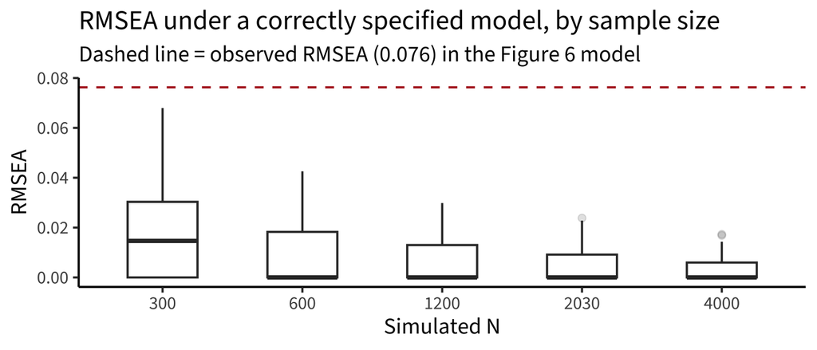

```r
null_by_n |>
  ggplot(aes(factor(n_obs), rmsea)) +
  geom_boxplot(outlier.alpha = .15, width = .5) +
  geom_hline(yintercept = fig6$rmsea, colour = "firebrick", linetype = 2) +
  labs(
    x = "Simulated N", y = "RMSEA",
    title = "RMSEA under a correctly specified model, by sample size",
    subtitle = glue("Dashed line = observed RMSEA ({round(fig6$rmsea, 3)}) in the Figure 6 model")
  )
```

## Check 3 — Do IRT theta measurement errors inflate the factor correlations?

Each indicator is an IRT ability estimate carrying measurement error. The concern is that ignoring this error distorts the latent correlations. Random, mutually uncorrelated measurement error is absorbed by CFA residual variances, so latent correlations should already be disattenuated. This check tests that on the fitted structure.

### Real marginal reliabilities

Reliabilities are taken from the `load-rxx` chunk of `_06-reliability.qmd` (the source of Table 6) and averaged across the groups reported there.

```r
# load-rxx blanks repeated task/itemtype/invariance labels for display;
# undo that so the table can be joined on.
task_rxx_clean <- task_rxx |>
  mutate(across(c(task, itemtype, invariance), \(x) na_if(as.character(x), ""))) |>
  fill(task, itemtype, invariance, .direction = "down")

rxx_by_task <- task_rxx_clean |>
  summarise(rxx = mean(empirical_rxx, na.rm = TRUE), n_groups = n(), .by = task) |>
  left_join(task_info |> distinct(item_task, task) |> mutate(task = as.character(task)),
            by = "task") |>
  filter(!is.na(item_task))

rxx_by_task |> mutate(rxx = round(rxx, 3)) |> arrange(item_task)
```

| task | rxx | n_groups | item_task |
| --- | --- | --- | --- |
| Hearts & Flowers | 0.905 | 4 | hf |
| Math | 0.927 | 4 | math |
| Pattern Matching | 0.718 | 4 | matrix |
| Memory | 0.762 | 4 | mg |
| Shape Rotation | 0.832 | 4 | mrot |
| Language Sounds | 0.840 | 2 | pa |
| Same & Different | 0.773 | 4 | sds |
| Sentence Reading | 0.711 | 3 | sre |
| Word Reading | 0.922 | 3 | swr |
| Stories | 0.656 | 4 | tom |

[output cut: 2 more lines]

### Simulating theta error on the real `fit_3f` structure

True factors are generated at a specified correlation; indicators are generated using the standardised loadings from `fit_3f`; each indicator then receives independent noise scaled so that its reliability equals that task’s marginal reliability. Measurement-error inflation would appear as recovered correlations systematically above the population value.

```r
structure_3f <- parameterEstimates(fit_3f, standardized = TRUE) |>
  filter(op == "=~") |>
  dplyr::select(factor = lhs, item_task = rhs, lambda = std.all)

measurement_syntax <- structure_3f |>
  summarise(rhs = paste(item_task, collapse = " + "), .by = factor) |>
  glue_data("{factor} =~ {rhs}") |>
  paste(collapse = "\n")

cat(measurement_syntax, "\n")
```

```
#> reasoning =~ mrot + matrix + math
#> ef =~ mg + sds + hf
#> language =~ vocab + trog + tom
```

```r
sim_spec <- structure_3f |>
  left_join(rxx_by_task |> dplyr::select(item_task, rxx), by = "item_task")

missing_rxx <- sim_spec |> filter(is.na(rxx)) |> pull(item_task)
if (length(missing_rxx)) {
  stop(glue(
    "No marginal reliability found for: {paste(missing_rxx, collapse = ', ')}. ",
    "These indicators appear in fit_3f but not in the Table 6 reliability output."
  ), call. = FALSE)
}

simulate_measurement_error <- function(spec, r_pop, n_obs, n_reps, seed) {
  factors <- unique(spec$factor)
  Phi <- matrix(r_pop, length(factors), length(factors),
                dimnames = list(factors, factors))
  diag(Phi) <- 1

  set.seed(seed)
  reps <- map(seq_len(n_reps), function(i) {
    F_true <- mvrnorm(n_obs, mu = rep(0, length(factors)), Sigma = Phi)
    colnames(F_true) <- factors

    obs <- map(seq_len(nrow(spec)), function(j) {
      lambda <- spec$lambda[j]
      rxx <- spec$rxx[j]
      # true task score: unit variance, lambda on its factor
      tau <- lambda * F_true[, spec$factor[j]] +
        rnorm(n_obs, sd = sqrt(max(0, 1 - lambda^2)))
      # theta error variance chosen so var(tau) / var(tau + e) == rxx
      tau + rnorm(n_obs, sd = sqrt((1 - rxx) / rxx))
    }) |>
      set_names(spec$item_task) |>
      as.data.frame()

    fit_i <- tryCatch(
      cfa(measurement_syntax, data = obs, estimator = "ML", std.lv = TRUE),
      error = function(e) NULL
    )
    if (is.null(fit_i) || !fit_is_proper(fit_i)) return(NULL)

    parameterEstimates(fit_i, standardized = TRUE) |>
      filter(op == "~~", lhs != rhs, lhs %in% factors, rhs %in% factors) |>
      transmute(pair = paste(lhs, rhs, sep = "-"), r_hat = std.all,
                r_pop = r_pop, rep = i)
  })

  n_ok <- sum(!map_lgl(reps, is.null))
  # Discarded replicates are not missing at random -- inadmissible solutions
  # cluster where the population correlation approaches 1 -- so a high discard
  # rate would itself bias the recovered mean. Surface it rather than hide it.
  if (n_ok < n_reps * 0.9) {
    warning(glue(
      "r_pop = {r_pop}: only {n_ok} of {n_reps} replicates gave a proper ",
      "solution. The recovered correlation for this condition is conditioned ",
      "on admissibility and should be read with that in mind."
    ))
  }

  reps |> compact() |> bind_rows() |>
    mutate(n_proper = n_ok, n_attempted = n_reps)
}

r_pop_grid <- c(.30, .50, .70, .85, .98)

me_results <- map(seq_along(r_pop_grid), function(k) {
  simulate_measurement_error(
    sim_spec, r_pop = r_pop_grid[k], n_obs = N_REAL,
    n_reps = N_REPS_ME, seed = SEED + 1000 * k
  )
}) |>
  bind_rows()

me_summary <- me_results |>
  summarise(
    r_hat_mean = mean(r_hat), r_hat_sd = sd(r_hat),
    bias = mean(r_hat) - first(r_pop),
    n_proper = first(n_proper), n_attempted = first(n_attempted),
    .by = c(r_pop, pair)
  ) |>
  arrange(r_pop, pair)

me_summary |> mutate(across(where(is.double), \(x) round(x, 4)))
```

| r_pop | pair | r_hat_mean | r_hat_sd | bias | n_proper | n_attempted |
| --- | --- | --- | --- | --- | --- | --- |
| 0.30 | ef-language | 0.3005 | 0.0306 | 0.0005 | 300 | 300 |
| 0.30 | reasoning-ef | 0.3022 | 0.0300 | 0.0022 | 300 | 300 |
| 0.30 | reasoning-language | 0.2980 | 0.0274 | -0.0020 | 300 | 300 |
| 0.50 | ef-language | 0.4978 | 0.0310 | -0.0022 | 300 | 300 |
| 0.50 | reasoning-ef | 0.4980 | 0.0280 | -0.0020 | 300 | 300 |
| 0.50 | reasoning-language | 0.5007 | 0.0229 | 0.0007 | 300 | 300 |
| 0.70 | ef-language | 0.6987 | 0.0240 | -0.0013 | 300 | 300 |
| 0.70 | reasoning-ef | 0.6991 | 0.0228 | -0.0009 | 300 | 300 |
| 0.70 | reasoning-language | 0.7016 | 0.0197 | 0.0016 | 300 | 300 |
| 0.85 | ef-language | 0.8518 | 0.0199 | 0.0018 | 300 | 300 |

[output cut: 5 more lines]

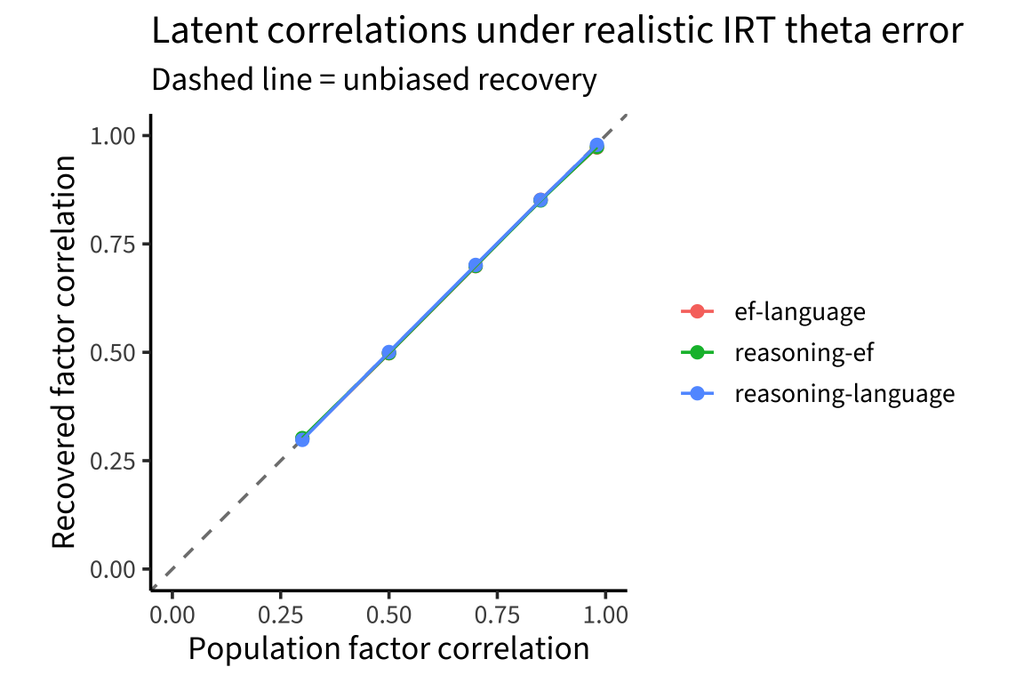

```r
me_summary |>
  ggplot(aes(r_pop, r_hat_mean, colour = pair)) +
  geom_abline(slope = 1, intercept = 0, linetype = 2, colour = "grey50") +
  geom_point(size = 2) +
  geom_line() +
  coord_equal(xlim = c(0, 1), ylim = c(0, 1)) +
  labs(
    x = "Population factor correlation", y = "Recovered factor correlation",
    colour = NULL,
    title = "Latent correlations under realistic IRT theta error",
    subtitle = "Dashed line = unbiased recovery"
  )
```

Observed correlations, for comparison:

```r
parameterEstimates(fit_3f, standardized = TRUE) |>
  filter(op == "~~", lhs != rhs, lhs %in% c("reasoning", "ef", "language"),
         rhs %in% c("reasoning", "ef", "language")) |>
  transmute(pair = paste(lhs, rhs, sep = "-"), r = round(std.all, 3))
```

| pair | r |
| --- | --- |
| reasoning-ef | 0.976 |
| reasoning-language | 0.887 |
| ef-language | 0.813 |

The `n_proper` and `n_attempted` columns should be inspected before interpreting any row. Inadmissible solutions concentrate in the highest condition: a population correlation near .98 leaves the factors nearly collinear and a substantial share of replicates fail `post.check`, while conditions from .30 to .85 converge cleanly. This parallels the Heywood behaviour reported in `_09-bifactor.qmd` for the direct bifactor model. Because discarded replicates are conditioned on admissibility, the recovered mean in a high-discard condition is not an unbiased estimate of bias.

Measurement-error inflation would place the simulated points above the diagonal, most visibly at low population correlations. The relevant quantities are the `bias` column and the distance from the dashed line.

## Check 4 — Does pooling across sites manufacture the correlations?

This analysis is George’s, reported in the manuscript as appendix `#apx-subsample` (`_10-subsample-robustness.qmd`). It is reproduced here for completeness, so that all six checks can be read together. The code below is borrowed from that file verbatim by `read_qmd_chunks()` rather than reimplemented, so these results are his analysis rather than a reconstruction of it.

Two designs address it. Equal-size-per-site subsampling removes the sample-size imbalance across sites. Within-site fits eliminate pooling entirely, and are the decisive test: with no aggregation, there can be no aggregation artifact.

```r
run_qmd_chunks(here("_10-subsample-robustness.qmd"),
               c("tbl-site-ns", "subsample-functions"))

site_ns |> rename(Site = site_label, N = n)
```

| Site | N |
| --- | --- |
| western-ca | 288 |
| mpieva-de | 347 |
| uniandes-co-bogota | 624 |
| uniandes-co-rural | 771 |

Note that `subsample-functions` redefines `fit_is_proper()`. The definition is equivalent to the one used elsewhere in this notebook except that it does not suppress `lavaan`’s warning, so the chunks below emit warnings where a replicate reaches an inadmissible solution.

```r
run_qmd_chunks(here("_10-subsample-robustness.qmd"), "subsample-refit")

full_sample_cors <- extract_cors_3f(fit_3f) |> rename(r_full = r)

subsample_results |>
  summarise(
    r_mean = mean(r), r_sd = sd(r),
    r_q025 = quantile(r, .025), r_q975 = quantile(r, .975),
    .by = pair
  ) |>
  left_join(full_sample_cors, by = "pair") |>
  mutate(across(where(is.double), \(x) round(x, 3)))
```

| pair | r_mean | r_sd | r_q025 | r_q975 | r_full |
| --- | --- | --- | --- | --- | --- |
| reasoning-ef | 0.954 | 0.013 | 0.929 | 0.977 | 0.976 |
| reasoning-language | 0.877 | 0.015 | 0.852 | 0.905 | 0.887 |
| ef-language | 0.782 | 0.022 | 0.731 | 0.825 | 0.813 |

```r
glue("{n_distinct(subsample_results$rep)} of {n_reps} replicates reached an ",
     "admissible solution, at n = {min_site_n} per site ",
     "({min_site_n * nrow(site_ns)} total per replicate).")
```

```
#> 197 of 200 replicates reached an admissible solution, at n = 288 per site (1152 total per replicate).
```

Balancing the sites leaves the full-sample estimates essentially unchanged, so the imbalance across sites is not responsible for the magnitude of the correlations.

```r
run_qmd_chunks(here("_10-subsample-robustness.qmd"), "within-site-fits")

# within-site-fits drops sites that fail, so refit here retaining every site
# and recording admissibility, since an inadmissible solution is itself
# informative rather than something to omit.
within_site_all <- site_ns |>
  filter(n >= 100) |>
  pull(site_label) |>
  map(function(s) {
    d <- filter(wide_scores, site_label == s)
    f <- tryCatch(fit_3f_on(d), error = function(e) NULL)
    if (is.null(f) || !isTRUE(lavInspect(f, "converged"))) {
      return(tibble(site_label = s, n = nrow(d), note = "did not converge"))
    }
    extract_cors_3f(f) |>
      mutate(site_label = s, n = nrow(d),
             admissible = isTRUE(suppressWarnings(lavInspect(f, "post.check"))))
  }) |>
  bind_rows()

within_site_all |>
  mutate(r = round(r, 3)) |>
  dplyr::select(site_label, n, pair, r, admissible) |>
  pivot_wider(names_from = pair, values_from = r) |>
  arrange(desc(n))
```

| site_label | n | admissible | reasoning-ef | reasoning-language | ef-language |
| --- | --- | --- | --- | --- | --- |
| uniandes-co-rural | 771 | FALSE | 1.254 | 0.853 | 1.001 |
| uniandes-co-bogota | 624 | FALSE | 0.958 | 0.819 | 0.562 |
| mpieva-de | 347 | TRUE | 0.861 | 0.690 | 0.524 |
| western-ca | 288 | TRUE | 0.940 | 0.813 | 0.663 |

### Interpretation

**Pooling does not create the correlations.** Within a single site, where no aggregation across sites is possible, Reasoning and Executive Function remain correlated between approximately .86 and .94 in the sites that produce admissible solutions. Equal-size subsampling likewise leaves the full-sample values close to unchanged.

**Pooling does inflate them modestly.** The within-site values are lower than the pooled estimate (.976), by roughly .04 to .12. Aggregation therefore contributes to the magnitude without accounting for it; a within-site correlation of .86 remains a substantial discriminant validity problem.

**The two Colombian sites return inadmissible solutions.** The rural site yields a Reasoning-EF correlation above 1, which is not a possible correlation. Those rows carry no information about the correlations and should be read only as evidence that the model is not estimable within those sites, which is consistent with the coverage figures in Check 5.

**The two methods of adjusting for site do not agree in magnitude.** Fitting within sites lowers the Reasoning-EF correlation; entering site as a covariate (Check 6) raises it. Site-as-covariate removes site differences in factor means while imposing a common covariance structure across sites, whereas within-site fits allow all parameters to differ. That the two diverge is further evidence of the between-site heterogeneity identified in Check 5, and indicates that “adjusting for site” is not a single well-defined operation for these data. The within-site result makes fewer assumptions and is the one to report; the direction of the conclusion is the same under both.

## Check 5 — Does the missingness pattern explain the misfit?

The analysis sample is substantially incomplete. This check tests whether that accounts for the fit indices. It does not: missingness masks misfit here rather than producing it.

### How much data each variable actually has

```r
model_vars <- colnames(lavInspect(fit_cov_age, "data"))

# Read each variable's role out of the fitted model rather than hardcoding it.
pe_fig6 <- parameterEstimates(fit_cov_age)
indicator_of <- pe_fig6 |> filter(op == "=~") |> dplyr::select(factor = lhs, var = rhs)
exogenous <- setdiff(pe_fig6$rhs[pe_fig6$op == "~"], c(indicator_of$var, ""))

coverage <- tibble(var = model_vars) |>
  left_join(indicator_of, by = "var") |>
  mutate(
    role = case_when(
      !is.na(factor) ~ paste(factor, "indicator"),
      var %in% exogenous ~ "exogenous predictor",
      TRUE ~ "observed outcome"
    ),
    n_obs = map_int(var, \(v) sum(!is.na(wide_scores[[v]]))),
    pct_missing = map_dbl(var, \(v) 100 * mean(is.na(wide_scores[[v]])))
  ) |>
  dplyr::select(var, role, n_obs, pct_missing) |>
  arrange(pct_missing)

coverage |> mutate(pct_missing = round(pct_missing, 1))
```

| var | role | n_obs | pct_missing |
| --- | --- | --- | --- |
| age_c | exogenous predictor | 2030 | 0.0 |
| math | observed outcome | 1867 | 8.0 |
| trog | language indicator | 1211 | 40.3 |
| vocab | language indicator | 1209 | 40.4 |
| hf | ef indicator | 1207 | 40.5 |
| mg | ef indicator | 1141 | 43.8 |
| mrot | reasoning indicator | 1139 | 43.9 |
| matrix | reasoning indicator | 1053 | 48.1 |
| tom | observed outcome | 744 | 63.3 |
| sds | ef indicator | 715 | 64.8 |

```r
task_vars <- setdiff(model_vars, exogenous)
k_task <- rowSums(!is.na(wide_scores[, task_vars, drop = FALSE]))

glue(
  "Of the {length(task_vars)} task scores, the typical child contributes ",
  "mean {round(mean(k_task), 2)} / median {median(k_task)}; ",
  "{sum(k_task == length(task_vars))} children ",
  "({round(100 * mean(k_task == length(task_vars)), 1)}%) have all of them."
)
```

```
#> Of the 9 task scores, the typical child contributes mean 5.07 / median 5; 300 children (14.8%) have all of them.
```

```r
table(`tasks observed` = k_task)
```

```
#> tasks observed
#>   1   2   3   4   5   6   7   8   9
#> 107 168 388 165 454 203 129 116 300
```

`age_c` is never missing, so including it would overstate coverage. The figures above cover the task scores only.

### The missingness is structured by site

```r
wide_scores |>
  summarise(
    n = n(),
    across(all_of(task_vars), \(x) round(100 * mean(is.na(x)))),
    .by = site_label
  ) |>
  arrange(desc(n))
```

| site_label | n | matrix | mrot | hf | mg | sds | trog | vocab | math | tom |
| --- | --- | --- | --- | --- | --- | --- | --- | --- | --- | --- |
| uniandes-co-rural | 771 | 62 | 61 | 67 | 62 | 97 | 53 | 47 | 7 | 89 |
| uniandes-co-bogota | 624 | 58 | 49 | 45 | 56 | 74 | 45 | 57 | 4 | 76 |
| mpieva-de | 347 | 13 | 18 | 3 | 7 | 5 | 22 | 16 | 12 | 11 |
| western-ca | 288 | 30 | 20 | 7 | 13 | 30 | 20 | 18 | 14 | 32 |

```r
wide_scores |>
  mutate(k = rowSums(!is.na(pick(all_of(task_vars))))) |>
  summarise(
    n = n(), mean_tasks = round(mean(k), 2), median_tasks = median(k),
    pct_complete = round(100 * mean(k == length(task_vars)), 1),
    .by = site_label
  ) |>
  arrange(desc(n))
```

| site_label | n | mean_tasks | median_tasks | pct_complete |
| --- | --- | --- | --- | --- |
| uniandes-co-rural | 771 | 3.55 | 3 | 0.0 |
| uniandes-co-bogota | 624 | 4.38 | 5 | 0.0 |
| mpieva-de | 347 | 7.94 | 9 | 63.7 |
| western-ca | 288 | 7.15 | 8 | 27.4 |

Coverage is not distributed evenly across the sample; it approximates a design variable. The two Colombian sites contribute most of the sample but few tasks per child, while the German and Canadian sites are substantially denser.

### Refitting where the data are dense

```r
fit_fig6_on <- function(data) {
  tryCatch(
    sem(model_cov_age, data = data, estimator = "MLR", missing = "fiml",
        std.lv = FALSE, optim.method = "nlminb",
        control = list(iter.max = 50000, rel.tol = 1e-6)),
    error = function(e) NULL
  )
}

summarise_subset <- function(data, label) {
  f <- fit_fig6_on(data)
  if (is.null(f) || !lavInspect(f, "converged")) {
    return(tibble(model = label, n = nrow(data), note = "did not converge"))
  }
  grab_measures(f, label) |>
    mutate(proper = isTRUE(suppressWarnings(lavInspect(f, "post.check"))))
}

dense_sites  <- c("mpieva-de", "western-ca")
sparse_sites <- setdiff(unique(as.character(wide_scores$site_label)), dense_sites)

density_fits <- bind_rows(
  summarise_subset(wide_scores, "All pooled"),
  map(sort(unique(as.character(wide_scores$site_label))),
      \(s) summarise_subset(filter(wide_scores, site_label == s), s)) |> bind_rows(),
  summarise_subset(filter(wide_scores, site_label %in% dense_sites), "Dense sites only"),
  summarise_subset(filter(wide_scores, site_label %in% sparse_sites), "Sparse sites only")
)

density_fits |>
  dplyr::select(model, n, df, chisq, cfi, rmsea, srmr, proper) |>
  mutate(across(where(is.double), \(x) round(x, 3)))
```

| model | n | df | chisq | cfi | rmsea | srmr | proper |
| --- | --- | --- | --- | --- | --- | --- | --- |
| All pooled | 2030 | 23 | 294.613 | 0.949 | 0.076 | 0.061 | TRUE |
| mpieva-de | 347 | 23 | 59.327 | 0.970 | 0.067 | 0.040 | TRUE |
| uniandes-co-bogota | 624 | 23 | 41.843 | 0.986 | 0.036 | 0.052 | FALSE |
| uniandes-co-rural | 771 | 23 | 30.178 | 0.995 | 0.020 | 0.208 | FALSE |
| western-ca | 288 | 23 | 25.819 | 0.998 | 0.021 | 0.023 | TRUE |
| Dense sites only | 635 | 23 | 152.624 | 0.947 | 0.094 | 0.045 | TRUE |
| Sparse sites only | 1395 | 23 | 41.732 | 0.993 | 0.024 | 0.037 | FALSE |

**RMSEA and SRMR diverge at the sparse sites.** The Colombian subsets return RMSEA of approximately .02 to .04 alongside improper solutions, and SRMR of approximately .21 at the rural site. With roughly 3.5 observed tasks per child there is little covariance structure available to misfit, so power to detect misspecification is low and RMSEA is correspondingly small. The `proper` column should be checked before these rows are interpreted.

**Pooling the two dense sites yields worse fit than either alone** (RMSEA .094 against .067 and .021), and worse than the full sample. This indicates between-site heterogeneity in covariance structure.

**Missingness does not account for the misfit.** Were it responsible, the sparse subsets would fit worst and the dense subsets best; the reverse holds. This agrees with Check 1, in which the null simulation imposes the observed missingness pattern on correctly specified data and returns RMSEA near zero.

Missingness does affect interpretation. The sample is dominated by sites contributing little covariance information, and FIML assumes data are missing at random conditional on the modelled variables. Site is not in this model and coverage depends strongly on site, so that assumption carries weight here. This is a limitation of interpretation and generalisability rather than an artifact accounting for the misfit.

## Check 6 — Are the factors empirically distinguishable?

Checks 1 to 5 test whether the reported values are artifacts. This check tests what the values imply. Two questions: whether the factor correlations are distinguishable from unity, and whether they survive adjustment for site.

### Interval estimates and a test against r = 1

Because `fit_3f` is fitted with `std.lv = TRUE`, factor variances are fixed at 1 and each factor covariance is itself the correlation, so `lavaan`’s confidence intervals apply directly to the correlations.

```r
parameterEstimates(fit_3f, standardized = TRUE, ci = TRUE, level = .95) |>
  filter(op == "~~", lhs != rhs,
         lhs %in% c("reasoning", "ef", "language"),
         rhs %in% c("reasoning", "ef", "language")) |>
  transmute(pair = paste(lhs, rhs, sep = "-"),
            r = std.all, se = se,
            ci_lower = ci.lower, ci_upper = ci.upper) |>
  mutate(across(where(is.double), \(x) round(x, 3)))
```

| pair | r | se | ci_lower | ci_upper |
| --- | --- | --- | --- | --- |
| reasoning-ef | 0.976 | 0.033 | 0.912 | 1.040 |
| reasoning-language | 0.887 | 0.022 | 0.844 | 0.930 |
| ef-language | 0.813 | 0.039 | 0.736 | 0.889 |

A correlation statistically indistinguishable from 1 means the two factors are not separable: a model merging them fits as well as one keeping them apart. The syntax below is regenerated from the `fit_3f` parameter table so the constrained and free models are guaranteed nested and identical apart from the single fixed correlation.

```r
build_3f_syntax <- function(fit, fixed_pair = NULL, fixed_value = 1) {
  pe <- parameterEstimates(fit)
  loads <- pe |> filter(op == "=~") |> dplyr::select(factor = lhs, ind = rhs)
  factors <- unique(loads$factor)
  preds <- setdiff(unique(pe$rhs[pe$op == "~"]), "")

  measurement <- map_chr(factors, \(f)
    glue("{f} =~ {paste(loads$ind[loads$factor == f], collapse = ' + ')}"))
  covariances <- combn(factors, 2, simplify = FALSE) |>
    map_chr(\(pr) if (!is.null(fixed_pair) && setequal(pr, fixed_pair))
      glue("{pr[1]} ~~ {fixed_value}*{pr[2]}") else glue("{pr[1]} ~~ {pr[2]}"))
  regressions <- map_chr(factors, \(f)
    glue("{f} ~ {paste(preds, collapse = ' + ')}"))

  paste(c(measurement, covariances, regressions), collapse = "\n")
}

fit_3f_syntax <- function(syntax) {
  sem(syntax, data = wide_scores, estimator = "MLR", missing = "fiml",
      std.lv = TRUE, optim.method = "nlminb",
      control = list(iter.max = 50000, rel.tol = 1e-6))
}

# Free model rebuilt from the parameter table; must reproduce fit_3f exactly.
fit_free <- fit_3f_syntax(build_3f_syntax(fit_3f))
stopifnot(isTRUE(all.equal(fitMeasures(fit_free)[["chisq"]],
                           fitMeasures(fit_3f)[["chisq"]], tolerance = 1e-4)))

factor_pairs <- combn(c("reasoning", "ef", "language"), 2, simplify = FALSE)

unity_tests <- map(factor_pairs, function(pr) {
  fit_con <- tryCatch(fit_3f_syntax(build_3f_syntax(fit_3f, pr)),
                      error = function(e) NULL)
  if (is.null(fit_con) || !lavInspect(fit_con, "converged")) {
    return(tibble(pair = paste(pr, collapse = "-"), note = "did not converge"))
  }
  lrt <- suppressWarnings(as.data.frame(lavTestLRT(fit_con, fit_free)))
  row <- lrt[!is.na(lrt[["Chisq diff"]]), ][1, ]
  tibble(
    pair        = paste(pr, collapse = "-"),
    chisq_diff  = row[["Chisq diff"]],
    df_diff     = row[["Df diff"]],
    p_value     = row[["Pr(>Chisq)"]],
    aic_free    = fitMeasures(fit_free)[["aic"]],
    aic_r1      = fitMeasures(fit_con)[["aic"]],
    bic_free    = fitMeasures(fit_free)[["bic"]],
    bic_r1      = fitMeasures(fit_con)[["bic"]],
    proper_r1   = isTRUE(suppressWarnings(lavInspect(fit_con, "post.check")))
  )
}) |> bind_rows()

unity_tests |> mutate(across(where(is.double), \(x) round(x, 3)))
```

| pair | chisq_diff | df_diff | p_value | aic_free | aic_r1 | bic_free | bic_r1 | proper_r1 |
| --- | --- | --- | --- | --- | --- | --- | --- | --- |
| reasoning-ef | 0.547 | 1 | 0.46 | 24224.85 | 24223.44 | 24410.17 | 24403.15 | FALSE |
| reasoning-language | 35.575 | 1 | 0.00 | 24224.85 | 24260.05 | 24410.17 | 24439.75 | FALSE |
| ef-language | 35.998 | 1 | 0.00 | 24224.85 | 24247.65 | 24410.17 | 24427.35 | FALSE |

A non-significant `p_value` indicates that fixing the correlation to 1 does not significantly degrade fit. Lower `aic_r1` / `bic_r1` than `aic_free` / `bic_free` indicates that the merged model is preferred on information criteria.

`proper_r1` is `FALSE` for every pair by construction, not as a diagnostic failure. Fixing one off-diagonal element of a 3 x 3 latent correlation matrix to 1 makes that matrix singular, so `post.check` necessarily reports a non-positive-definite latent covariance matrix. This is the intended constraint rather than an estimation problem, and is the one place in this notebook where a `FALSE` in a `proper` column should not be treated as grounds for discarding the result.

### Site as a covariate

An alternative to a multi-group model is to enter site as dummy predictors alongside age. This removes between-site differences in factor *means*, so the residual factor correlations are net of site composition. It does not model between-site differences in covariance structure, which is the heterogeneity identified in Check 5.

```r
d_site <- wide_scores |> mutate(site_label = fct_drop(site_label))
site_dummies <- model.matrix(~ site_label, data = d_site)[, -1, drop = FALSE]
colnames(site_dummies) <- paste0("site", seq_len(ncol(site_dummies)))
d_site <- bind_cols(d_site, as.data.frame(site_dummies))

reference_site <- levels(d_site$site_label)[1]
site_terms <- paste(colnames(site_dummies), collapse = " + ")

mdl_3f_site <- glue("
reasoning =~ mrot + matrix + math
ef        =~ mg + sds + hf
language  =~ vocab + trog + tom
reasoning ~~ ef + language
ef ~~ language
reasoning ~ age_c + {site_terms}
ef        ~ age_c + {site_terms}
language  ~ age_c + {site_terms}
")

fit_3f_site <- sem(mdl_3f_site, data = d_site, estimator = "MLR",
                   missing = "fiml", std.lv = TRUE, optim.method = "nlminb",
                   control = list(iter.max = 50000, rel.tol = 1e-6))

glue("Reference site: {reference_site}; {ncol(site_dummies)} dummy predictors. ",
     "Proper solution: {isTRUE(suppressWarnings(lavInspect(fit_3f_site, 'post.check')))}")
```

```
#> Reference site: mpieva-de; 3 dummy predictors. Proper solution: TRUE
```

```r
extract_cors <- function(fit, label) {
  parameterEstimates(fit, standardized = TRUE) |>
    filter(op == "~~", lhs != rhs,
           lhs %in% c("reasoning", "ef", "language"),
           rhs %in% c("reasoning", "ef", "language")) |>
    transmute(pair = paste(lhs, rhs, sep = "-"), !!label := round(std.all, 3))
}

left_join(extract_cors(fit_3f, "age_only"),
          extract_cors(fit_3f_site, "age_plus_site"), by = "pair")
```

| pair | age_only | age_plus_site |
| --- | --- | --- |
| reasoning-ef | 0.976 | 0.999 |
| reasoning-language | 0.887 | 0.813 |
| ef-language | 0.813 | 0.750 |

```r
bind_rows(grab_measures(fit_3f, "age only"),
          grab_measures(fit_3f_site, "age + site")) |>
  dplyr::select(model, n, df, chisq, cfi, rmsea, srmr) |>
  mutate(across(where(is.double), \(x) round(x, 3)))
```

| model | n | df | chisq | cfi | rmsea | srmr |
| --- | --- | --- | --- | --- | --- | --- |
| age only | 2030 | 30 | 371.316 | 0.936 | 0.075 | 0.063 |
| age + site | 2030 | 48 | 1199.358 | 0.833 | 0.109 | 0.090 |

```r
round(lavInspect(fit_3f_site, "r2")[c("reasoning", "ef", "language")], 3)
```

```
#> reasoning        ef  language
#>     0.575     0.529     0.480
```

The `r2` values give the proportion of each factor’s variance attributable to age and site jointly, indexing how much of the between-person variance is associated with sampling site.

### Interpretation

Three results follow.

**The failure of discriminant validity is specific to one factor pair.** Reasoning and Executive Function are not statistically distinguishable: the confidence interval for their correlation includes 1, constraining it to 1 does not significantly degrade fit, and both AIC and BIC favour the constrained model. The other two pairs are clearly distinguishable, with the r = 1 constraint strongly rejected in each case and both information criteria favouring the free model. Language is therefore separable from both Reasoning and Executive Function; the three-factor structure fails only in that it does not separate Reasoning from Executive Function. This is a more precise statement of the problem than the magnitude of the correlations alone.

**Adjusting for site does not reduce the collinearity.** Site accounts for a substantial share of factor variance, but the Reasoning-EF correlation increases rather than decreases once site is partialled out. The collinearity is therefore within-site, not a product of pooling heterogeneous samples. This should be read alongside the within-site fits in Check 4, which move the correlation in the opposite direction. The Reasoning-Language and EF-Language correlations decrease, indicating that site composition inflates them: adjusting for site improves Language’s separation from the other two factors rather than reducing it.

**Adjusting for site degrades fit.** Dummy covariates constrain factor means across sites but impose a common covariance structure, which Check 5 shows does not hold. The site-covariate specification is therefore informative about the correlations but is not a remedy for the misfit.

A constraint on interpretation: pairwise coverage for the indicator pairs that identify the Reasoning-EF distinction is low (see Check 5), and each factor has three indicators. “Not distinguishable from r = 1” is therefore consistent with two readings — that the constructs are not separable in this population, or that these data lack the information to separate them. The present design does not adjudicate between them.

```r
cov_mat <- lavInspect(fit_3f, "coverage")
r_inds  <- c("mrot", "matrix", "math")
e_inds  <- c("mg", "sds", "hf")

glue(
  "Pairwise coverage for Reasoning x EF indicator pairs: ",
  "min {round(min(cov_mat[r_inds, e_inds]), 2)}, ",
  "median {round(median(cov_mat[r_inds, e_inds]), 2)}, ",
  "max {round(max(cov_mat[r_inds, e_inds]), 2)}."
)
```

```
#> Pairwise coverage for Reasoning x EF indicator pairs: min 0.24, median 0.32, max 0.56.
```

```r
round(cov_mat[c(r_inds, e_inds), c(r_inds, e_inds)], 2)
```

```
#>        mrot matrix math   mg  sds   hf
#> mrot   0.56   0.28 0.53 0.47 0.26 0.31
#> matrix 0.28   0.52 0.50 0.28 0.24 0.45
#> math   0.53   0.50 0.92 0.53 0.32 0.56
#> mg     0.47   0.28 0.53 0.56 0.30 0.34
#> sds    0.26   0.24 0.32 0.30 0.35 0.34
#> hf     0.31   0.45 0.56 0.34 0.34 0.59
```

## Summary

```r
tibble(
  check = c(
    "1. Low df inflates RMSEA",
    "2. Large N inflates chi-square",
    "3. IRT theta error inflates factor correlations",
    "4. Site pooling manufactures the correlations",
    "5. Missingness drives the misfit",
    "6. Factors are empirically distinguishable"
  ),
  target = c("fit_cov_age", "fit_cov_age", "fit_3f", "fit_3f", "fit_cov_age",
             "fit_3f"),
  evidence = c(
    glue("df = {DF_REAL}; null RMSEA median {round(median(null_fig6$rmsea), 3)}, ",
         "95th pct {round(quantile(null_fig6$rmsea, .95), 3)} vs observed {round(fig6$rmsea, 3)}"),
    glue("Null rejection rate near .05 at every N; null RMSEA ~0 at N = {N_REAL}"),
    glue("Max |bias| across conditions = {round(max(abs(me_summary$bias)), 3)}"),
    glue("Within-site fits (no pooling) still give Reasoning-EF ",
         "{paste(round(range(within_site_all$r[within_site_all$pair == 'reasoning-ef' & within_site_all$admissible], na.rm = TRUE), 2), collapse = '-')}; ",
         "equal-size subsampling leaves full-sample values near unchanged"),
    glue("Runs the other way: sparse sites show better RMSEA but improper ",
         "solutions; dense sites pooled are worse ",
         "({round(density_fits$rmsea[density_fits$model == 'Dense sites only'], 3)}) ",
         "than the full sample ({round(fig6$rmsea, 3)})"),
    glue("Reasoning-EF r = 1 not rejected ",
         "(p = {round(unity_tests$p_value[unity_tests$pair == 'reasoning-ef'], 2)}, ",
         "AIC/BIC favour the constraint); other two pairs clearly separable ",
         "(p < .001); adjusting for site raises Reasoning-EF, not lowers it")
  )
)
```

| check | target | evidence |
| --- | --- | --- |
| 1. Low df inflates RMSEA | fit_cov_age | df = 23; null RMSEA median 0, 95th pct 0.016 vs observed 0.076 |
| 2. Large N inflates chi-square | fit_cov_age | Null rejection rate near .05 at every N; null RMSEA ~0 at N = 2030 |
| 3. IRT theta error inflates factor correlations | fit_3f | Max \|bias\| across conditions = 0.007 |
| 4. Site pooling manufactures the correlations | fit_3f | Within-site fits (no pooling) still give Reasoning-EF 0.86-0.94; equal-size subsampling leaves full-sample values near unchanged |
| 5. Missingness drives the misfit | fit_cov_age | Runs the other way: sparse sites show better RMSEA but improper solutions; dense sites pooled are worse (0.094) than the full sample (0.076) |
| 6. Factors are empirically distinguishable | fit_3f | Reasoning-EF r = 1 not rejected (p = 0.46, AIC/BIC favour the constraint); other two pairs clearly separable (p < .001); adjusting for site raises Reasoning-EF, not lowers it |

All values are recomputed at each render from the fitted models.

Checks 1, 2, 3 and 5 test candidate artifacts; none accounts for the reported misfit or the magnitude of the correlations. Check 4, reproduced from George’s appendix analysis, shows that pooling across sites inflates the correlations modestly but does not produce them. Check 6 localises the discriminant validity problem: Reasoning and Executive Function are not statistically distinguishable, this does not arise from pooling across sites, and the remaining two factor pairs are clearly separable.

The general-factor account in `_09-bifactor.qmd` (appendix `#apx-bifactor`) is consistent with these results, subject to the identification constraint noted in Check 6: with three indicators per factor and low pairwise coverage, the data cannot distinguish non-separable constructs from insufficient information to separate them.

Check 5 additionally identifies between-site heterogeneity in covariance structure as a contributor to the misfit, which is not addressed by the existing robustness analyses.

## Domain-specific models: EF and Language (exploratory)

The sections above concern the main construct-validity SEM. This section concerns the two *external-validity* models in `_08-sem.qmd` (`fit_ef` and `fit_lang`).

**These results have since been adopted in the manuscript.** Figures 7 and 8 now show spec A (the measurement model, no age), and Table 8 reports the spec A and spec C loadings side by side as an age control. Spec B, which the manuscript previously used, has been dropped: the age slope it contributed is developmental-sensitivity evidence already covered by the age-models section, and it answers a developmental rather than a validity question. The comparison below is what motivated that change.

### Data note: the MEFS score labels are wrong upstream

The `metric_type` labels in `scores_mefs.rds` do not match what they contain. Confirmed with Mike (2026-10-09) as a known upstream issue, and consistent with the MEFS Technical Report (Reflection Sciences, *MEFS Technical Report 2026*, v. 07.26.26), which documents three distinct scores: a **Total Score** (0-100, combining trial accuracy and response time via a proprietary algorithm), a **U.S. National Percentile** (referenced to same-age-in-months US norms), and a **National Standard Score** (M = 100, SD = 15).

| Label in the data | Actual score | Evidence in this sample |
| --- | --- | --- |
| `standard_score` | Total Score | climbs with age (+3.6 pts/year, R² = .29), max 94 |
| `total_score` | U.S. National Percentile | flat with age (R² = .007), roughly uniform 0-85 |

The National Standard Score is not present in the data at all. (The manuscript cites @carlson2021 as the general MEFS reference; the score definitions and reliability figures used here are from the 2026 edition of the technical report, which is the version consulted.) The models below use the Total Score (labelled `standard_score`), which is the appropriate choice for a model containing age: the percentile is already age-referenced, so its age variance has been removed, and being a rank transform it is also non-linearly related to the underlying scale.

```r
# Not cached: this chunk re-runs chunks borrowed from _08-sem.qmd, whose
# contents can change without this chunk's own code changing -- which would
# otherwise leave a stale cache silently reporting a superseded specification.
#| dependson: rebuild-models

run_qmd_chunks(here("_08-sem.qmd"), c("prep-sem-ef", "prep-sem-lang"))

mefs_raw <- read_rds(here(pilots_dir, "02_scoring_outputs/scores/scores_mefs.rds")) |>
  dplyr::select(user_id, age, metric_type, metric_value) |>
  pivot_wider(names_from = metric_type, values_from = metric_value,
              values_fn = first) |>
  filter(!is.na(age))

# Documents the label problem rather than assuming the reader takes it on trust.
map(c("standard_score", "total_score"), function(v) {
  fit <- lm(mefs_raw[[v]] ~ mefs_raw$age)
  tibble(label = v,
         slope_per_year = coef(fit)[[2]],
         r2_age = summary(fit)$r.squared,
         median = median(mefs_raw[[v]], na.rm = TRUE),
         sd = sd(mefs_raw[[v]], na.rm = TRUE),
         max = max(mefs_raw[[v]], na.rm = TRUE))
}) |> bind_rows() |> mutate(across(where(is.double), \(x) round(x, 3)))
```

| label | slope_per_year | r2_age | median | sd | max |
| --- | --- | --- | --- | --- | --- |
| standard_score | 3.594 | 0.288 | 73 | 14.771 | 94 |
| total_score | -0.798 | 0.007 | 41 | 21.711 | 85 |

```r
mefs_raw |>
  mutate(band = cut(age, c(5, 7, 9, 11, 14), right = FALSE,
                    labels = c("5-6", "7-8", "9-10", "11-13"))) |>
  summarise(n = n(),
            mean_total_score = round(mean(standard_score, na.rm = TRUE), 1),
            mean_percentile = round(mean(total_score, na.rm = TRUE), 1),
            .by = band) |>
  arrange(band)
```

| band | n | mean_total_score | mean_percentile |
| --- | --- | --- | --- |
| 5-6 | 72 | 62.2 | 43.6 |
| 7-8 | 90 | 72.3 | 41.3 |
| 9-10 | 64 | 79.2 | 34.9 |
| 11-13 | 52 | 84.0 | 40.2 |

The age bands make the point without any modelling: the variable labelled `standard_score` rises monotonically across age while the one labelled `total_score` does not.

### The manuscript’s EF and Language models

For reference, the two domain-specific models as specified in `_08-sem.qmd`, reproduced here by borrowing the manuscript’s own fitting and plotting chunks so the diagrams match the paper exactly.

```r
# Not cached: this chunk re-runs chunks borrowed from _08-sem.qmd, whose
# contents can change without this chunk's own code changing -- which would
# otherwise leave a stale cache silently reporting a superseded specification.
#| results: "hide"

# The manuscript's plotting chunks call get_nodes() and read_excel() unqualified,
# relying on ms.qmd's setup; load them here so the borrowed chunks run as written.
library(tidySEM)
library(readxl)

run_qmd_chunks(here("_08-sem.qmd"), c("sem-ef", "sem-lang"))
```

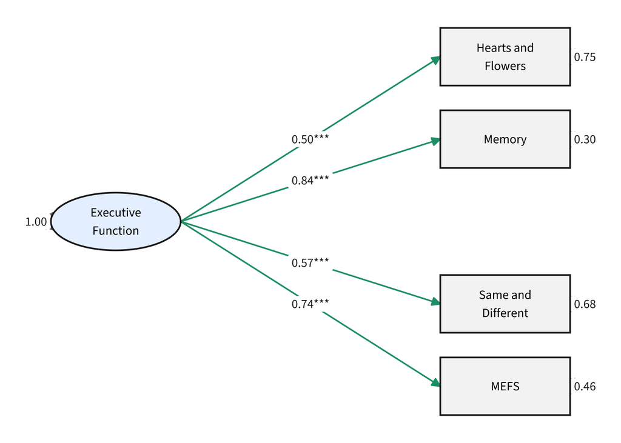

Figure 1

```r
# Not cached: this chunk re-runs chunks borrowed from _08-sem.qmd, whose
# contents can change without this chunk's own code changing -- which would
# otherwise leave a stale cache silently reporting a superseded specification.
#| fig-cap: "Executive Function model as specified in the manuscript (`fit_ef`)."
#| fig-width: 7
#| fig-height: 5

# sem-ef-plot only builds and styles the graph object; ms.qmd draws it in a
# separate chunk, so plot() is called explicitly here.
run_qmd_chunks(here("_08-sem.qmd"), "sem-ef-plot")
plot(g_ef)
```

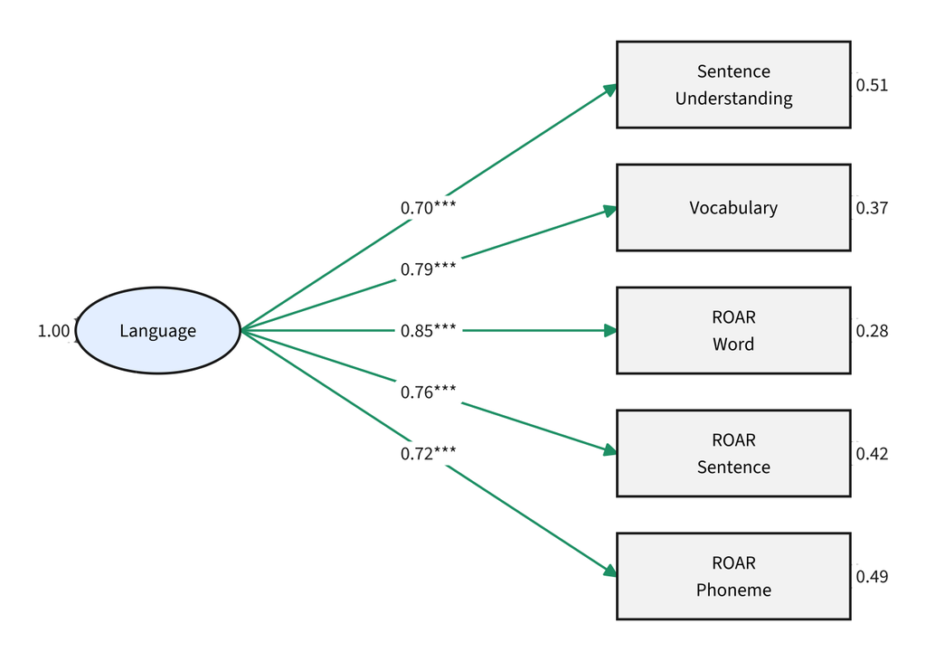

Figure 2

```r
# Not cached: this chunk re-runs chunks borrowed from _08-sem.qmd, whose
# contents can change without this chunk's own code changing -- which would
# otherwise leave a stale cache silently reporting a superseded specification.
#| fig-cap: "Language model as specified in the manuscript (`fit_lang`)."
#| fig-width: 7
#| fig-height: 5

run_qmd_chunks(here("_08-sem.qmd"), "sem-lang-plot")
plot(g_lang)
```

### How age enters the model: three specifications

Age can enter these models in three defensible ways, and they answer different questions.

| Spec | Specification | Question | Status in the manuscript |
| --- | --- | --- | --- |
| A | factor only, no age | baseline measurement model | Figures 7-8 |
| B | `factor ~ age` | how much factor variance is developmental | dropped (was used previously) |
| C | `indicator ~ age` for every indicator | does the factor cohere beyond shared age-related growth? | Table 8, age-controlled column |

B leaves age-driven covariance among the indicators intact, so it does not test whether the factor is distinguishable from shared developmental growth. C removes age from each indicator and estimates the factor from what remains. Across an age range of 5 to 13 years this distinction is substantive.

```r
build_age_specs <- function(factor_name, indicators) {
  measurement <- glue("{factor_name} =~ {paste(indicators, collapse = ' + ')}")
  list(
    `A no age`          = as.character(measurement),
    `B age -> factor`   = paste(measurement, glue("{factor_name} ~ age"), sep = "\n"),
    `C age -> indicators` = paste(measurement,
                                  paste(glue("{indicators} ~ age"), collapse = "\n"),
                                  sep = "\n")
  )
}

fit_domain <- function(syntax, data) {
  tryCatch(
    sem(syntax, data = data, estimator = "MLR", missing = "fiml",
        std.lv = TRUE, optim.method = "nlminb",
        control = list(iter.max = 50000, rel.tol = 1e-6)),
    error = function(e) NULL
  )
}

summarise_domain <- function(fits) {
  imap(fits, function(f, lab) {
    if (is.null(f) || !isTRUE(lavInspect(f, "converged")))
      return(tibble(spec = lab, note = "did not converge"))
    grab_measures(f, lab) |>
      dplyr::select(spec = model, df, chisq, cfi, rmsea, srmr) |>
      mutate(proper = isTRUE(suppressWarnings(lavInspect(f, "post.check"))))
  }) |> bind_rows()
}

loadings_domain <- function(fits) {
  imap(fits, function(f, lab) {
    if (is.null(f)) return(tibble())
    parameterEstimates(f, standardized = TRUE) |>
      filter(op == "=~") |>
      transmute(indicator = rhs, spec = lab, lambda = round(std.all, 3))
  }) |> bind_rows() |> pivot_wider(names_from = spec, values_from = lambda)
}

ef_indicators   <- c("hf", "mg", "sds", "mefs")
lang_indicators <- c("swr", "sre", "pa", "trog", "vocab")

ef_fits <- build_age_specs("EF", ef_indicators) |>
  map(\(syn) fit_domain(syn, ef_wide_scores))
lang_fits <- build_age_specs("Language", lang_indicators) |>
  map(\(syn) fit_domain(syn, lang_wide_scores))
```

### Diagrams for the three specifications

The three diagrams below show the same four (or five) tasks arranged the same way each time: age on the left, the factor in the middle, the tasks on the right. Only the arrows change.

- **Spec A** has no age at all. It asks: do these tasks hang together?
- **Spec B** has one arrow from age into the factor. It asks: how much of the factor is developmental?
- **Spec C** has an arrow from age into every task separately. It asks: do the tasks still hang together once each one’s own age-related growth has been taken out?

The numbers on the arrows from the factor to each task are loadings: how strongly that task reflects the factor, on a scale where 1 would be perfect. Watch what happens to those numbers between B and C.

```r
# The manuscript's plotting chunks are written for one model each, with node
# positions read from Excel. These specifications have different node sets
# (Spec A has no age) and different edges, so the layout is built in code here
# and the styling from `sem-ef-plot` is reused.
pretty_labels <- c(
  age = "Age\n(years)", EF = "Executive\nFunction", Language = "Language",
  hf = "Hearts and\nFlowers", mg = "Memory", sds = "Same and\nDifferent",
  mefs = "MEFS", swr = "ROAR\nWord", sre = "ROAR\nSentence",
  pa = "ROAR\nPhoneme", trog = "Sentence\nUnderstanding", vocab = "Vocabulary"
)

plot_domain_spec <- function(fit, factor_name, indicators) {
  nodes <- get_nodes(fit, columns = c("name", "shape")) |>
    mutate(label = coalesce(unname(pretty_labels[name]), name))

  edges <- parameterEstimates(fit, standardized = TRUE) |>
    filter(op %in% c("~", "=~", "~~")) |>
    transmute(
      lhs, rhs, op,
      from = if_else(op == "~", rhs, lhs),
      to   = if_else(op == "~", lhs, rhs),
      std.all, pvalue,
      arrow     = if_else(op == "~~" & lhs != rhs, "none",
                          if_else(op == "~~", "both", "last")),
      curvature = if_else(op == "~~" & lhs != rhs, 50, NA_real_),
      linetype  = if_else(op == "~~" & lhs != rhs, 2, 1),
      label = if_else(
        op %in% c("~", "=~"),
        sprintf("%.2f%s", std.all,
                case_when(pvalue < .001 ~ "***", pvalue < .01 ~ "**",
                          pvalue < .05 ~ "*", TRUE ~ "")),
        sprintf("%.2f", std.all))
    )

  # age left, factor centre, indicators right; blank column if age is absent
  has_age <- "age" %in% nodes$name
  # Indicators are spaced on alternate rows and the factor placed on a row
  # between them: if the factor sits level with an indicator it covers that
  # indicator's arrows and its loading label becomes unreadable.
  nr <- length(indicators) + 1
  mid <- ceiling(nr / 2)
  lay <- matrix("", nrow = nr, ncol = 3)
  lay[setdiff(seq_len(nr), mid), 3] <- indicators
  lay[mid, 2] <- factor_name
  if (has_age) lay[mid, 1] <- "age"
  lay <- lay[, colSums(lay != "") > 0, drop = FALSE]

  g <- tidySEM::prepare_graph(
    edges = edges, nodes = nodes, layout = lay,
    text_size = 3.2, rect_width = 7, rect_height = 3.5,
    ellipses_width = 7, ellipses_height = 3.5,
    variance_height = 2.5, variance_width = 2,
    arrow_angle = 15, arrow_length = .2,
    var_arrow_angle = 15, var_arrow_length = .1,
    spacing_y = 5, spacing_x = 7, fix_coord = FALSE
  )
  g$nodes$fill <- case_when(g$nodes$shape == "oval" ~ "#E8F2FF",
                            g$nodes$name == "age"   ~ "#FFF2E0",
                            TRUE ~ "#F5F5F5")
  g$nodes$colour <- "#1F1F1F"; g$nodes$font <- "#1F1F1F"
  g$edges$colour <- case_when(g$edges$op == "=~" ~ "#1B9E77",
                              g$edges$op == "~"  ~ "#386CB0",
                              TRUE ~ "#6B6B6B")
  g$edges$linetype <- if_else(g$edges$op == "~~", 2L, 1L)
  g$edges$size <- 0.6
  g$nodes$geom_text <- TRUE
  g$edges$label_fill <- "white"
  g$edges$label_colour <- "#1F1F1F"
  g$edges$label_alpha <- 1
  g
}
```

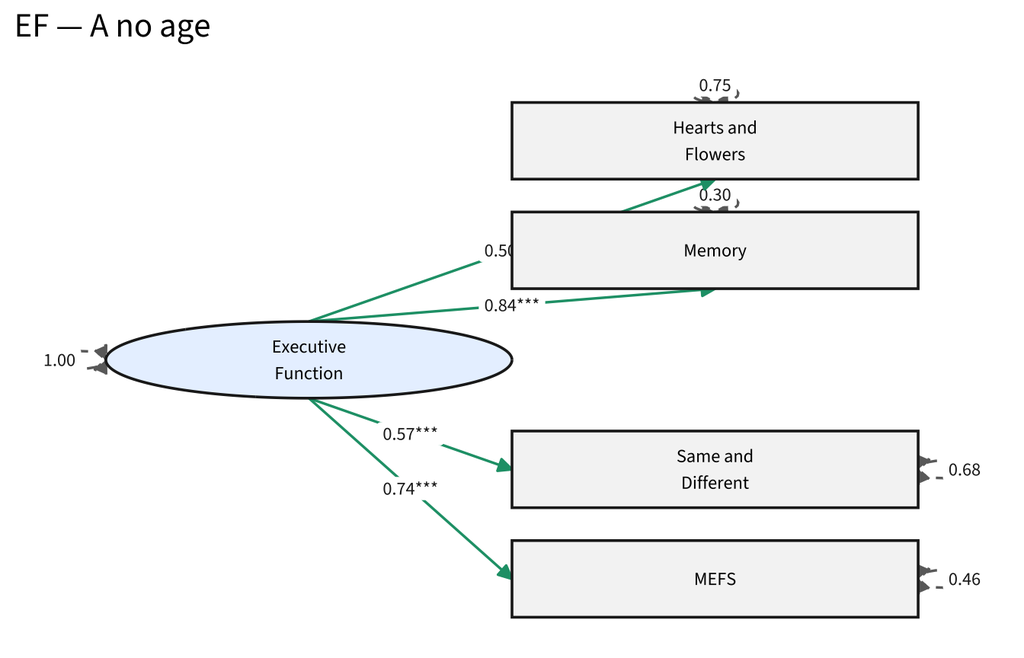

Figure 3: Executive Function under the three specifications. Spec A has no age; Spec B sends age to the factor; Spec C sends age to each task. Loadings on the factor-to-task arrows are standardised.

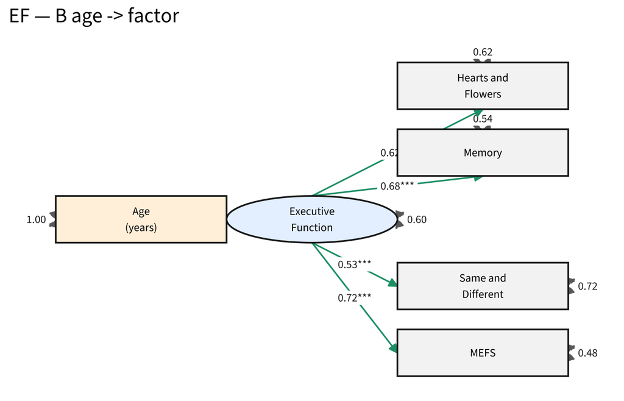

Figure 4: Executive Function under the three specifications. Spec A has no age; Spec B sends age to the factor; Spec C sends age to each task. Loadings on the factor-to-task arrows are standardised.

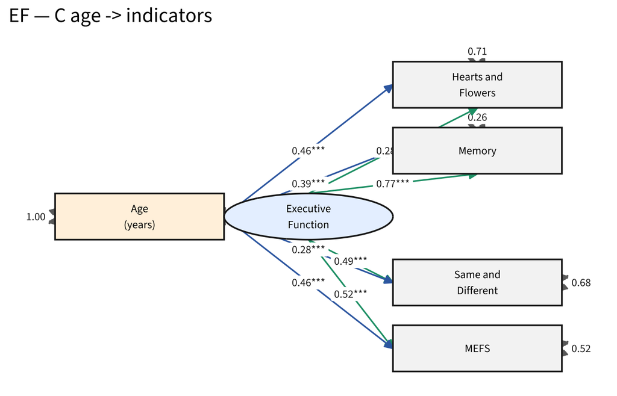

Figure 5: Executive Function under the three specifications. Spec A has no age; Spec B sends age to the factor; Spec C sends age to each task. Loadings on the factor-to-task arrows are standardised.

```r
for (nm in names(ef_fits)) {
  f <- ef_fits[[nm]]
  if (is.null(f)) next
  print(plot_domain_spec(f, "EF", ef_indicators) |> plot() +
          ggplot2::labs(title = paste("EF —", nm)))
}
```

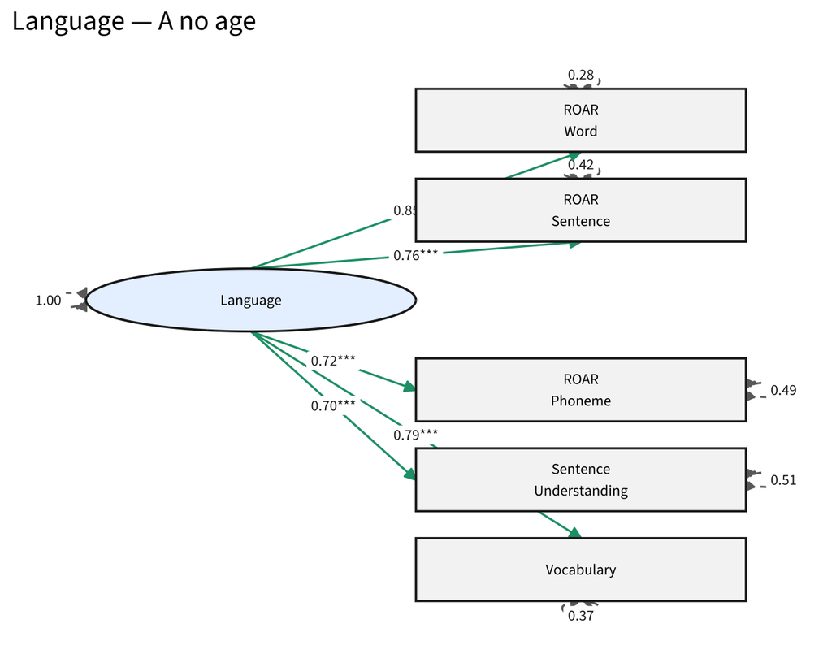

Figure 6: Language under the three specifications, arranged as above.

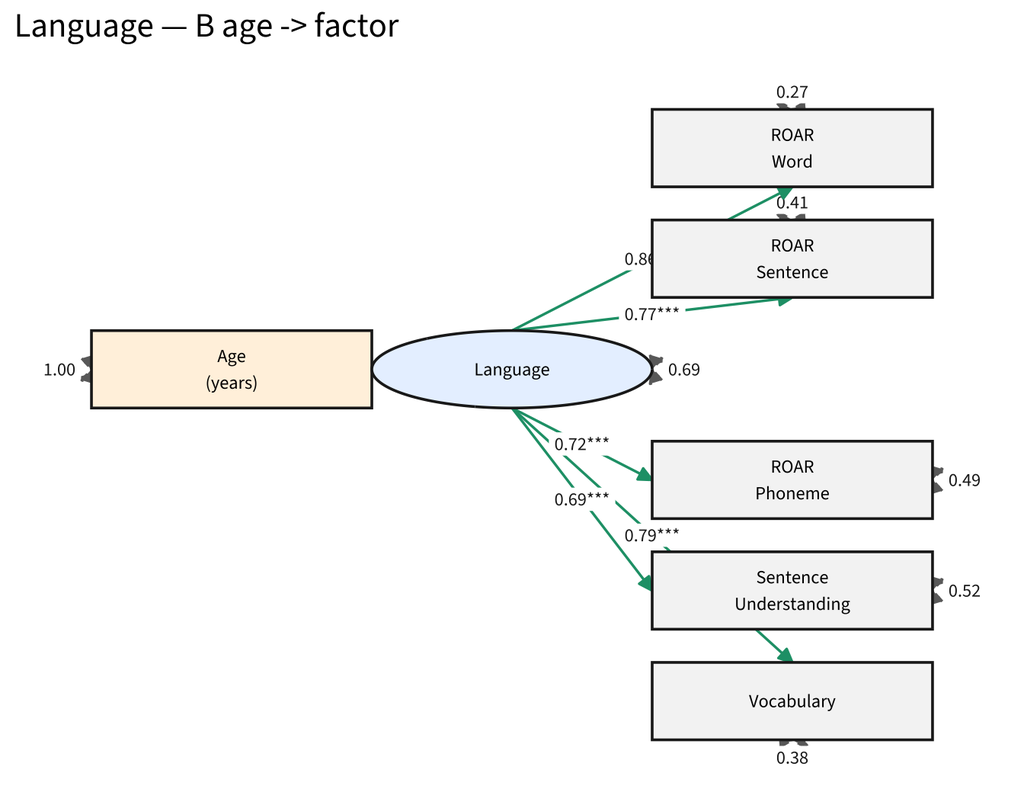

Figure 7: Language under the three specifications, arranged as above.

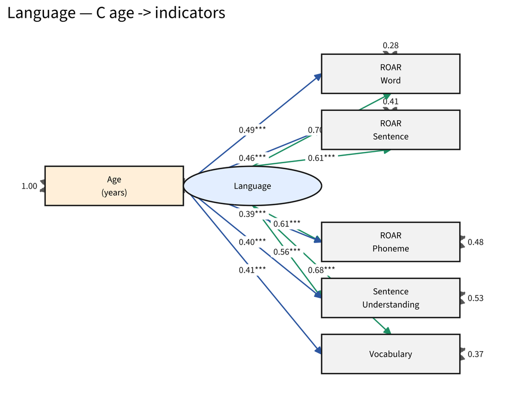

Figure 8: Language under the three specifications, arranged as above.

```r
for (nm in names(lang_fits)) {
  f <- lang_fits[[nm]]
  if (is.null(f)) next
  print(plot_domain_spec(f, "Language", lang_indicators) |> plot() +
          ggplot2::labs(title = paste("Language —", nm)))
}
```

```r
glue("EF models, n = {nrow(ef_wide_scores)} ",
     "({sum(!is.na(ef_wide_scores$mefs))} with MEFS)")
```

```
#> EF models, n = 1677 (278 with MEFS)
```

```r
summarise_domain(ef_fits) |> mutate(across(where(is.double), \(x) round(x, 3)))
```

| spec | df | chisq | cfi | rmsea | srmr | proper |
| --- | --- | --- | --- | --- | --- | --- |
| A no age | 2 | 8.082 | 0.986 | 0.043 | 0.023 | TRUE |
| B age -> factor | 5 | 61.574 | 0.934 | 0.082 | 0.050 | TRUE |
| C age -> indicators | 2 | 3.852 | 0.998 | 0.023 | 0.014 | TRUE |

```r
loadings_domain(ef_fits)
```

| indicator | A no age | B age -> factor | C age -> indicators |
| --- | --- | --- | --- |
| hf | 0.498 | 0.618 | 0.276 |
| mg | 0.839 | 0.677 | 0.766 |
| sds | 0.568 | 0.528 | 0.491 |
| mefs | 0.738 | 0.723 | 0.515 |

```r
glue("Language models, n = {nrow(lang_wide_scores)}")
```

```
#> Language models, n = 1961
```

```r
summarise_domain(lang_fits) |> mutate(across(where(is.double), \(x) round(x, 3)))
```

| spec | df | chisq | cfi | rmsea | srmr | proper |
| --- | --- | --- | --- | --- | --- | --- |
| A no age | 5 | 95.775 | 0.963 | 0.096 | 0.036 | TRUE |
| B age -> factor | 9 | 109.684 | 0.966 | 0.076 | 0.034 | TRUE |
| C age -> indicators | 5 | 101.264 | 0.968 | 0.099 | 0.031 | TRUE |

```r
loadings_domain(lang_fits)
```

| indicator | A no age | B age -> factor | C age -> indicators |
| --- | --- | --- | --- |
| swr | 0.851 | 0.855 | 0.697 |
| sre | 0.762 | 0.771 | 0.610 |
| pa | 0.716 | 0.717 | 0.607 |
| trog | 0.702 | 0.689 | 0.562 |
| vocab | 0.793 | 0.786 | 0.678 |

How much age variance each indicator carries, which determines how far its loading moves between specifications:

```r
age_dependence <- function(data, indicators, domain) {
  map(indicators, function(v) {
    r <- cor(data[[v]], data$age, use = "pairwise.complete.obs")
    tibble(domain = domain, indicator = v, r_age = r, r2_age = r^2)
  }) |> bind_rows()
}

bind_rows(
  age_dependence(ef_wide_scores, ef_indicators, "EF"),
  age_dependence(lang_wide_scores, lang_indicators, "Language")
) |>
  mutate(across(where(is.double), \(x) round(x, 3)))
```

| domain | indicator | r_age | r2_age |
| --- | --- | --- | --- |
| EF | hf | 0.473 | 0.224 |
| EF | mg | 0.365 | 0.133 |
| EF | sds | 0.354 | 0.126 |
| EF | mefs | 0.533 | 0.285 |
| Language | swr | 0.471 | 0.222 |
| Language | sre | 0.441 | 0.195 |
| Language | pa | 0.357 | 0.127 |
| Language | trog | 0.405 | 0.164 |
| Language | vocab | 0.405 | 0.164 |

Spec B is nested within spec C: B constrains age’s association with each indicator to operate entirely through the factor, which C leaves free. The constraint is therefore testable.

```r
compare_b_c <- function(fits, domain) {
  B <- fits[["B age -> factor"]]
  C <- fits[["C age -> indicators"]]
  if (is.null(B) || is.null(C)) return(tibble(domain = domain, note = "model missing"))
  lrt <- suppressWarnings(as.data.frame(lavTestLRT(B, C)))
  row <- lrt[!is.na(lrt[["Chisq diff"]]), ][1, ]
  tibble(
    domain = domain,
    df_B = fitMeasures(B)[["df"]], df_C = fitMeasures(C)[["df"]],
    chisq_diff = row[["Chisq diff"]], df_diff = row[["Df diff"]],
    p_value = row[["Pr(>Chisq)"]],
    aic_B = fitMeasures(B)[["aic"]], aic_C = fitMeasures(C)[["aic"]],
    bic_B = fitMeasures(B)[["bic"]], bic_C = fitMeasures(C)[["bic"]]
  )
}

bind_rows(compare_b_c(ef_fits, "EF"), compare_b_c(lang_fits, "Language")) |>
  mutate(across(where(is.double), \(x) round(x, 3)))
```

| domain | df_B | df_C | chisq_diff | df_diff | p_value | aic_B | aic_C | bic_B | bic_C |
| --- | --- | --- | --- | --- | --- | --- | --- | --- | --- |
| EF | 5 | 2 | 74.835 | 3 | 0.000 | 8703.998 | 8652.276 | 8774.52 | 8739.073 |
| Language | 9 | 5 | 6.793 | 4 | 0.147 | 15782.783 | 15782.362 | 15872.08 | 15893.986 |

```r
# Proportion of factor variance attributable to age under spec B.
tibble(
  domain = c("EF", "Language"),
  r2_age_on_factor = c(
    lavInspect(ef_fits[["B age -> factor"]], "r2")[["EF"]],
    lavInspect(lang_fits[["B age -> factor"]], "r2")[["Language"]]
  )
) |> mutate(r2_age_on_factor = round(r2_age_on_factor, 3))
```

| domain | r2_age_on_factor |
| --- | --- |
| EF | 0.399 |
| Language | 0.315 |

#### Interpretation

**Spec B’s constraint is rejected for EF but not for Language.** For the EF model, allowing age to predict each indicator directly improves fit by far more than the three degrees of freedom it costs, and both information criteria prefer spec C. For the Language model the constraint is not rejected, and BIC prefers the more parsimonious spec B. Spec B was therefore adequate for Language but not for EF, where age’s association with the tasks does not operate solely through the factor. This asymmetry is one reason the manuscript now reports spec A alongside spec C for both domains rather than relying on spec B for either: a specification that is defensible in one domain and rejected in the other is a poor basis for a side-by-side validity claim.

**The Language factor does not show this pattern.** All five loadings remain strong under spec C, so Language coheres independently of age. This is not because the Language indicators carry less age variance – Word Reading (r = .47) is as age-dependent as Hearts and Flowers (r = .47) – but because the Language tasks retain substantial shared variance once age is removed, whereas Hearts and Flowers largely does not.

#### What these specifications license as claims

Two claims are available in principle: that the battery measures a *developmental* construct, and that it measures *individual differences* in that construct. The three specifications bear on them differently, and the two domains come out differently.

**For EF, neither holds in unqualified form.** The rejection of spec B is itself evidence against the developmental-construct reading: that reading implies age acts on the tasks *through* a common dimension, which is the constraint spec B imposes and the data reject. Age’s associations with the four tasks are task-specific. Separately, a correlation with age is weak evidence of construct validity in any case – most cognitive tasks show one, and the age trends are already reported in `_05-age_models.qmd`. Construct validity is a claim about covariance structure rather than about age slopes.

The individual-differences reading is partly supported for EF. Under spec C, Memory, Same and Different, and MEFS retain substantial loadings, so a common dimension does exist among children of the same age, and the MEFS loading provides corroboration from an independent instrument rather than from internal structure alone. Hearts and Flowers does not participate in that dimension.

The defensible statement for EF is therefore narrower than for Language: Memory, Same and Different and MEFS share individual-difference variance beyond age-related growth, supporting a common executive function dimension; Hearts and Flowers does not contribute to it once age is controlled; and age’s associations with the tasks are task-specific rather than mediated by a single factor.

Note also that the EF evidence leans on age more heavily than the Language evidence does – 39.9% of factor variance against 31.5%, combined with an indicator that does not survive age partialling. These results are specification comparisons on the same data, not evidence that any one specification is correct.

### MEFS as a latent variable

An alternative separates them, so that the quantity of interest is a correlation between two constructs:

```
EF_levante =~ hf + mg + sds
MEFS_lat   =~ 1*mefs          # residual variance fixed from reliability
EF_levante ~~ MEFS_lat        # the validity coefficient
```

Because MEFS has a single indicator, its residual variance is not identified and must be fixed. The task scores are standardised by `prep_sem()`, so the residual variance is `1 - rxx` for an assumed reliability `rxx`.

**On the choice of `rxx`.** The MEFS Technical Report (2026, v. 07.26.26) gives no internal consistency estimate – plausibly because the adaptive, accuracy-and-response-time algorithm does not admit one – and reports only test-retest ICCs, which vary by sample, age range, device and delay: .93 (ages 2.5-5, same day, table-top), .95 (ages 2-5, table-top vs tablet), .92 (ages 3-15, two-week gap, NIH Toolbox levels), .73 (ages 2+, 11-90 days, N = 2,034), and .86 / .85 / .85 / .71 / .70 by increasing delay (N = 333). None corresponds to the present sample, which is ages 5-13, tablet-administered, and partly in Spanish and German outside the US norming population.

Two further considerations argue against adopting any single value. The report describes the .73 estimate as deflated, because those children were enrolled in studies and programmes that may have acted as EF interventions. And test-retest reliability is the wrong coefficient for this purpose: measured over an interval it absorbs genuine developmental change as well as measurement error, so it understates single-occasion reliability and over-corrects the correlation.

The analysis is therefore reported as a sensitivity range, with `rxx = 1` (no correction) included as the reference case. That reference case is the quantity that requires no assumption, and it is a lower bound.

```r
mefs_latent_fit <- function(rxx, with_age) {
  syntax <- glue(
    "EF_levante =~ 1*hf + mg + sds\n",
    "MEFS_lat =~ 1*mefs\n",
    "mefs ~~ {round(1 - rxx, 4)}*mefs\n",
    "EF_levante ~~ MEFS_lat",
    if (with_age) "\nEF_levante ~ age\nMEFS_lat ~ age" else ""
  )
  f <- tryCatch(
    sem(syntax, data = ef_wide_scores, estimator = "MLR", missing = "fiml",
        std.lv = FALSE, optim.method = "nlminb",
        control = list(iter.max = 50000, rel.tol = 1e-6)),
    error = function(e) NULL
  )
  if (is.null(f) || !isTRUE(lavInspect(f, "converged")))
    return(tibble(rxx = rxx, age = with_age, note = "did not converge"))

  r <- parameterEstimates(f, standardized = TRUE) |>
    filter(op == "~~", lhs == "EF_levante", rhs == "MEFS_lat") |>
    pull(std.all)

  tibble(rxx = rxx, age = with_age, r_EF_MEFS = r,
         cfi = fitMeasures(f)[["cfi"]], rmsea = fitMeasures(f)[["rmsea"]],
         proper = isTRUE(suppressWarnings(lavInspect(f, "post.check"))))
}

rxx_grid <- c(.70, .73, .80, .85, .90, .95, 1.00)

mefs_sensitivity <- expand_grid(rxx = rxx_grid, with_age = c(FALSE, TRUE)) |>
  pmap(\(rxx, with_age) mefs_latent_fit(rxx, with_age)) |>
  bind_rows()

# Fit is constant across rxx within each age condition (fixing a residual
# variance consumes no df), so it is reported separately rather than repeated.
mefs_sensitivity |>
  mutate(age = if_else(age, "age on both factors", "no age")) |>
  dplyr::select(rxx, age, r_EF_MEFS) |>
  pivot_wider(names_from = age, values_from = r_EF_MEFS) |>
  mutate(across(where(is.double), \(x) round(x, 3)))
```

| rxx | no age | age on both factors |
| --- | --- | --- |
| 0.70 | 0.878 | 0.835 |
| 0.73 | 0.861 | 0.809 |
| 0.80 | 0.823 | 0.756 |
| 0.85 | 0.799 | 0.724 |
| 0.90 | 0.777 | 0.696 |
| 0.95 | 0.757 | 0.671 |
| 1.00 | 0.738 | 0.648 |

```r
mefs_sensitivity |>
  summarise(cfi = first(cfi), rmsea = first(rmsea),
            all_proper = all(proper), .by = age) |>
  mutate(age = if_else(age, "age on both factors", "no age"),
         across(where(is.double), \(x) round(x, 3)))
```

| age | cfi | rmsea | all_proper |
| --- | --- | --- | --- |
| no age | 0.986 | 0.043 | TRUE |
| age on both factors | 0.932 | 0.093 | TRUE |

```r
ref <- mefs_sensitivity |> filter(rxx == 1, !age)
rng <- mefs_sensitivity |> filter(!age) |> pull(r_EF_MEFS) |> range()

glue(
  "Reference case (no correction for MEFS unreliability): ",
  "r(EF_levante, MEFS) = {round(ref$r_EF_MEFS, 3)}. ",
  "Across assumed reliabilities of {min(rxx_grid)} to 1.00 the estimate ranges ",
  "from {round(rng[1], 3)} to {round(rng[2], 3)}."
)
```

```
#> Reference case (no correction for MEFS unreliability): r(EF_levante, MEFS) = 0.738. Across assumed reliabilities of 0.7 to 1.00 the estimate ranges from 0.738 to 0.878.
```

#### Interpretation

Fit is unaffected by `rxx`, since fixing a residual variance consumes no degrees of freedom and the model-implied covariance structure among the observed variables is unchanged.

Note that the models including age fit considerably worse than those without, and give lower correlations throughout. This is the same pattern as spec B versus spec C above: constraining age to act through the factors does not describe these data well.

## Reproducibility

```r
glue("Rendered: {Sys.time()}")
```

```
#> Rendered: 2026-10-23 14:53:08.798665
```

```r
glue("Seed: {SEED}; null replicates: {N_REPS_NULL}; measurement-error replicates: {N_REPS_ME}")
```

```
#> Seed: 20260207; null replicates: 500; measurement-error replicates: 300
```